# case_study_1-How_do_members_use_bikes_differently_than_non-members

James R

2024-08-07

## Data Integrity, cleaning and verification documentation for the following task:

### How do annual members and casual riders use Cyclistic bikes differently?

This document is to provide the documentation and steps used in the data integrity, cleaning and verification for the tasked analysis of “How do annual members and casual riders use Cyclistic bikes differently?”

Below the steps will be outlined along with comment/explanations regarding what steps were taken and why or results found and anything notable that could have an effect on the analysis

## Data Preperation

*Step 1 - Gather the data The data used for this analysis was obtained through download via a provided link to the hosting website. The data is public data and has been made available by Motivate International Inc. under this license[link] https://www.divvybikes.com/data-license-agreement.

*Step 3 - prepare the data Here we are going to analyse the 5 .csv files for data cleaning and integrity checks to ensure this is data that can be used for the task.First however we must prepare the R environment by installing and loading the appropriate packages so we can work with the data sets.

*Note:* We will work under the assumption that the R environment is loaded with base R packages only. If you are running this R Markdown on another computer you may already have the packages installed and loaded in your active R environment

#### installing and loading the packages

```r
##only run the install packages for packages that are not currently installed to your environment
## install.packages("tidyverse")
## install.packages("conflicted")
## install.packages("dplyr")
## install.packages("ggplot2")
## install.packages("lubridate")
## install.packages("tidyr")
## install.packages("scales")
## install.packages("RColorBrewer")


library(tidyverse)  #helps wrangle data (it has key data transformation functions)
library(conflicted) # Use the conflicted package to manage conflicts
library(dplyr) #a package for making data manipulation easier
library(ggplot2)
library(lubridate)
library(tidyr)
library(scales)
library(RColorBrewer)

# Set dplyr::filter and dplyr::lag as the default choices
conflict_prefer("filter", "dplyr")
```

```
## [conflicted] Will prefer dplyr::filter over any other package.
```

```r
conflict_prefer("lag", "dplyr")
```

```
## [conflicted] Will prefer dplyr::lag over any other package.
```

#### loading the raw datasets

```r
q1_2019 <- read_csv("Divvy_Trips_2019_Q1.csv")
q2_2019 <- read_csv("Divvy_Trips_2019_Q2.csv")
q3_2019 <- read_csv("Divvy_Trips_2019_Q3.csv")
q4_2019 <- read_csv("Divvy_Trips_2019_Q4.csv")
q1_2020 <- read_csv("Divvy_Trips_2020_Q1.csv")
```

# Data cleaning and integrity verification

Here we will analysis the 5 datsets for content, column naming conventions and other issues such as inconsistencies, missing data, data type and formatting.

###==================================================== ## WRANGLE THE DATA AND COMBINE IT INTO A SINGLE FILE ###==================================================== Here we will Compare column names and the column data type(s) for each of the files. This will help us check for inconsistent and/or incomplete data before compiling it all into 1 large data set

```r
colnames(q1_2019)
```

```
##  [1] "trip_id"           "start_time"        "end_time"
##  [4] "bikeid"            "tripduration"      "from_station_id"
##  [7] "from_station_name" "to_station_id"     "to_station_name"
## [10] "usertype"          "gender"            "birthyear"
```

```r
colnames(q2_2019)
```

```
##  [1] "01 - Rental Details Rental ID"
##  [2] "01 - Rental Details Local Start Time"
##  [3] "01 - Rental Details Local End Time"
##  [4] "01 - Rental Details Bike ID"
##  [5] "01 - Rental Details Duration In Seconds Uncapped"
##  [6] "03 - Rental Start Station ID"
##  [7] "03 - Rental Start Station Name"
##  [8] "02 - Rental End Station ID"
##  [9] "02 - Rental End Station Name"
## [10] "User Type"
## [11] "Member Gender"
## [12] "05 - Member Details Member Birthday Year"
```

```r
colnames(q3_2019)
```

```
##  [1] "trip_id"           "start_time"        "end_time"
##  [4] "bikeid"            "tripduration"      "from_station_id"
##  [7] "from_station_name" "to_station_id"     "to_station_name"
## [10] "usertype"          "gender"            "birthyear"
```

```r
colnames(q4_2019)
```

```
##  [1] "trip_id"           "start_time"        "end_time"
##  [4] "bikeid"            "tripduration"      "from_station_id"
##  [7] "from_station_name" "to_station_id"     "to_station_name"
## [10] "usertype"          "gender"            "birthyear"
```

```r
colnames(q1_2020)
```

```
##  [1] "ride_id"            "rideable_type"      "started_at"
##  [4] "ended_at"           "start_station_name" "start_station_id"
##  [7] "end_station_name"   "end_station_id"     "start_lat"
## [10] "start_lng"          "end_lat"            "end_lng"
## [13] "member_casual"
```

***Observation 1:** there are different column names being used for the same data across the data sets - we will need to rename some columns within the data sets to make them consistent - I have chosen q1_2020 to be the standard (as this will be the going-forward table design for Divvy data per the assignment documentation)

Now we will inspect the data frames and look for incongruities

```r
str(q1_2019)
```

```
## spc_tbl_ [365,069 × 12] (S3: spec_tbl_df/tbl_df/tbl/data.frame)
##  $ trip_id          : num [1:365069] 21742443 21742444 21742445 21742446 21742447 ...
##  $ start_time       : POSIXct[1:365069], format: "2019-01-01 00:04:37" "2019-01-01 00:08:13" ...
##  $ end_time         : POSIXct[1:365069], format: "2019-01-01 00:11:07" "2019-01-01 00:15:34" ...
##  $ bikeid           : num [1:365069] 2167 4386 1524 252 1170 ...
##  $ tripduration     : num [1:365069] 390 441 829 1783 364 ...
##  $ from_station_id  : num [1:365069] 199 44 15 123 173 98 98 211 150 268 ...
##  $ from_station_name: chr [1:365069] "Wabash Ave & Grand Ave" "State St & Randolph St" "Racine Ave & 18th St" "California Ave & Milwaukee Ave" ...
##  $ to_station_id    : num [1:365069] 84 624 644 176 35 49 49 142 148 141 ...
##  $ to_station_name  : chr [1:365069] "Milwaukee Ave & Grand Ave" "Dearborn St & Van Buren St (*)" "Western Ave & Fillmore St (*)" "Clark St & Elm St" ...
##  $ usertype         : chr [1:365069] "Subscriber" "Subscriber" "Subscriber" "Subscriber" ...
##  $ gender           : chr [1:365069] "Male" "Female" "Female" "Male" ...
##  $ birthyear        : num [1:365069] 1989 1990 1994 1993 1994 ...
##  - attr(*, "spec")=
##   .. cols(
##   ..   trip_id = col_double(),
##   ..   start_time = col_datetime(format = ""),
##   ..   end_time = col_datetime(format = ""),
##   ..   bikeid = col_double(),
##   ..   tripduration = col_number(),
##   ..   from_station_id = col_double(),
##   ..   from_station_name = col_character(),
##   ..   to_station_id = col_double(),
##   ..   to_station_name = col_character(),
##   ..   usertype = col_character(),
##   ..   gender = col_character(),
##   ..   birthyear = col_double()
##   .. )
##  - attr(*, "problems")=<externalptr>
```

```r
str(q2_2019)
```

```
## spc_tbl_ [1,108,163 × 12] (S3: spec_tbl_df/tbl_df/tbl/data.frame)
##  $ 01 - Rental Details Rental ID                   : num [1:1108163] 22178529 22178530 22178531 22178532 22178533 ...
##  $ 01 - Rental Details Local Start Time            : POSIXct[1:1108163], format: "2019-04-01 00:02:22" "2019-04-01 00:03:02" ...
##  $ 01 - Rental Details Local End Time              : POSIXct[1:1108163], format: "2019-04-01 00:09:48" "2019-04-01 00:20:30" ...
##  $ 01 - Rental Details Bike ID                     : num [1:1108163] 6251 6226 5649 4151 3270 ...
##  $ 01 - Rental Details Duration In Seconds Uncapped: num [1:1108163] 446 1048 252 357 1007 ...
##  $ 03 - Rental Start Station ID                    : num [1:1108163] 81 317 283 26 202 420 503 260 211 211 ...
##  $ 03 - Rental Start Station Name                  : chr [1:1108163] "Daley Center Plaza" "Wood St & Taylor St" "LaSalle St & Jackson Blvd" "McClurg Ct & Illinois St" ...
##  $ 02 - Rental End Station ID                      : num [1:1108163] 56 59 174 133 129 426 500 499 211 211 ...
##  $ 02 - Rental End Station Name                    : chr [1:1108163] "Desplaines St & Kinzie St" "Wabash Ave & Roosevelt Rd" "Canal St & Madison St" "Kingsbury St & Kinzie St" ...
##  $ User Type                                       : chr [1:1108163] "Subscriber" "Subscriber" "Subscriber" "Subscriber" ...
##  $ Member Gender                                   : chr [1:1108163] "Male" "Female" "Male" "Male" ...
##  $ 05 - Member Details Member Birthday Year        : num [1:1108163] 1975 1984 1990 1993 1992 ...
##  - attr(*, "spec")=
##   .. cols(
##   ..   `01 - Rental Details Rental ID` = col_double(),
##   ..   `01 - Rental Details Local Start Time` = col_datetime(format = ""),
##   ..   `01 - Rental Details Local End Time` = col_datetime(format = ""),
##   ..   `01 - Rental Details Bike ID` = col_double(),
##   ..   `01 - Rental Details Duration In Seconds Uncapped` = col_number(),
##   ..   `03 - Rental Start Station ID` = col_double(),
##   ..   `03 - Rental Start Station Name` = col_character(),
##   ..   `02 - Rental End Station ID` = col_double(),
##   ..   `02 - Rental End Station Name` = col_character(),
##   ..   `User Type` = col_character(),
##   ..   `Member Gender` = col_character(),
##   ..   `05 - Member Details Member Birthday Year` = col_double()
##   .. )
##  - attr(*, "problems")=<externalptr>
```

```r
str(q3_2019)
```

```
## spc_tbl_ [1,640,718 × 12] (S3: spec_tbl_df/tbl_df/tbl/data.frame)
##  $ trip_id          : num [1:1640718] 23479388 23479389 23479390 23479391 23479392 ...
##  $ start_time       : POSIXct[1:1640718], format: "2019-07-01 00:00:27" "2019-07-01 00:01:16" ...
##  $ end_time         : POSIXct[1:1640718], format: "2019-07-01 00:20:41" "2019-07-01 00:18:44" ...
##  $ bikeid           : num [1:1640718] 3591 5353 6180 5540 6014 ...
##  $ tripduration     : num [1:1640718] 1214 1048 1554 1503 1213 ...
##  $ from_station_id  : num [1:1640718] 117 381 313 313 168 300 168 313 43 43 ...
##  $ from_station_name: chr [1:1640718] "Wilton Ave & Belmont Ave" "Western Ave & Monroe St" "Lakeview Ave & Fullerton Pkwy" "Lakeview Ave & Fullerton Pkwy" ...
##  $ to_station_id    : num [1:1640718] 497 203 144 144 62 232 62 144 195 195 ...
##  $ to_station_name  : chr [1:1640718] "Kimball Ave & Belmont Ave" "Western Ave & 21st St" "Larrabee St & Webster Ave" "Larrabee St & Webster Ave" ...
##  $ usertype         : chr [1:1640718] "Subscriber" "Customer" "Customer" "Customer" ...
##  $ gender           : chr [1:1640718] "Male" NA NA NA ...
##  $ birthyear        : num [1:1640718] 1992 NA NA NA NA ...
##  - attr(*, "spec")=
##   .. cols(
##   ..   trip_id = col_double(),
##   ..   start_time = col_datetime(format = ""),
##   ..   end_time = col_datetime(format = ""),
##   ..   bikeid = col_double(),
##   ..   tripduration = col_number(),
##   ..   from_station_id = col_double(),
##   ..   from_station_name = col_character(),
##   ..   to_station_id = col_double(),
##   ..   to_station_name = col_character(),
##   ..   usertype = col_character(),
##   ..   gender = col_character(),
##   ..   birthyear = col_double()
##   .. )
##  - attr(*, "problems")=<externalptr>
```

```r
str(q4_2019)
```

```
## spc_tbl_ [704,054 × 12] (S3: spec_tbl_df/tbl_df/tbl/data.frame)
##  $ trip_id          : num [1:704054] 25223640 25223641 25223642 25223643 25223644 ...
##  $ start_time       : POSIXct[1:704054], format: "2019-10-01 00:01:39" "2019-10-01 00:02:16" ...
##  $ end_time         : POSIXct[1:704054], format: "2019-10-01 00:17:20" "2019-10-01 00:06:34" ...
##  $ bikeid           : num [1:704054] 2215 6328 3003 3275 5294 ...
##  $ tripduration     : num [1:704054] 940 258 850 2350 1867 ...
##  $ from_station_id  : num [1:704054] 20 19 84 313 210 156 84 156 156 336 ...
##  $ from_station_name: chr [1:704054] "Sheffield Ave & Kingsbury St" "Throop (Loomis) St & Taylor St" "Milwaukee Ave & Grand Ave" "Lakeview Ave & Fullerton Pkwy" ...
##  $ to_station_id    : num [1:704054] 309 241 199 290 382 226 142 463 463 336 ...
##  $ to_station_name  : chr [1:704054] "Leavitt St & Armitage Ave" "Morgan St & Polk St" "Wabash Ave & Grand Ave" "Kedzie Ave & Palmer Ct" ...
##  $ usertype         : chr [1:704054] "Subscriber" "Subscriber" "Subscriber" "Subscriber" ...
##  $ gender           : chr [1:704054] "Male" "Male" "Female" "Male" ...
##  $ birthyear        : num [1:704054] 1987 1998 1991 1990 1987 ...
##  - attr(*, "spec")=
##   .. cols(
##   ..   trip_id = col_double(),
##   ..   start_time = col_datetime(format = ""),
##   ..   end_time = col_datetime(format = ""),
##   ..   bikeid = col_double(),
##   ..   tripduration = col_number(),
##   ..   from_station_id = col_double(),
##   ..   from_station_name = col_character(),
##   ..   to_station_id = col_double(),
##   ..   to_station_name = col_character(),
##   ..   usertype = col_character(),
##   ..   gender = col_character(),
##   ..   birthyear = col_double()
##   .. )
##  - attr(*, "problems")=<externalptr>
```

```r
str(q1_2020)
```

```
## spc_tbl_ [426,887 × 13] (S3: spec_tbl_df/tbl_df/tbl/data.frame)
##  $ ride_id           : chr [1:426887] "EACB19130B0CDA4A" "8FED874C809DC021" "789F3C21E472CA96" "C9A388DAC6ABF313" ...
##  $ rideable_type     : chr [1:426887] "docked_bike" "docked_bike" "docked_bike" "docked_bike" ...
##  $ started_at        : POSIXct[1:426887], format: "2020-01-21 20:06:59" "2020-01-30 14:22:39" ...
##  $ ended_at          : POSIXct[1:426887], format: "2020-01-21 20:14:30" "2020-01-30 14:26:22" ...
##  $ start_station_name: chr [1:426887] "Western Ave & Leland Ave" "Clark St & Montrose Ave" "Broadway & Belmont Ave" "Clark St & Randolph St" ...
##  $ start_station_id  : num [1:426887] 239 234 296 51 66 212 96 96 212 38 ...
##  $ end_station_name  : chr [1:426887] "Clark St & Leland Ave" "Southport Ave & Irving Park Rd" "Wilton Ave & Belmont Ave" "Fairbanks Ct & Grand Ave" ...
##  $ end_station_id    : num [1:426887] 326 318 117 24 212 96 212 212 96 100 ...
##  $ start_lat         : num [1:426887] 42 42 41.9 41.9 41.9 ...
##  $ start_lng         : num [1:426887] -87.7 -87.7 -87.6 -87.6 -87.6 ...
##  $ end_lat           : num [1:426887] 42 42 41.9 41.9 41.9 ...
##  $ end_lng           : num [1:426887] -87.7 -87.7 -87.7 -87.6 -87.6 ...
##  $ member_casual     : chr [1:426887] "member" "member" "member" "member" ...
##  - attr(*, "spec")=
##   .. cols(
##   ..   ride_id = col_character(),
##   ..   rideable_type = col_character(),
##   ..   started_at = col_datetime(format = ""),
##   ..   ended_at = col_datetime(format = ""),
##   ..   start_station_name = col_character(),
##   ..   start_station_id = col_double(),
##   ..   end_station_name = col_character(),
##   ..   end_station_id = col_double(),
##   ..   start_lat = col_double(),
##   ..   start_lng = col_double(),
##   ..   end_lat = col_double(),
##   ..   end_lng = col_double(),
##   ..   member_casual = col_character()
##   .. )
##  - attr(*, "problems")=<externalptr>
```

**Observation 2:** ‘member_casual’ has 2 different phrases used to represent membership vs non-membership - we need to convert to 1 standard for both data sets **Observation 3:** ride_id is a ‘num’ in all the 2019 and as ‘chr’ in q1_2020 - need to correct so it is standard across all **Observation 4:** rideable_type is a ‘num’ in all the 2019 and as ‘chr’ in q1_2020 - we will need to correct so it is standard across all **Observation 5:** we notice the following columns don’t exist in in all the 2019 - “start_lat”, “start_lng”, “end_lat”, “end_lng” ***Observation 6:** we notice the following columns don’t exist in q1_2020 - “tripduration”, “gender”, “birthyear”

Now we need to address the observations. In this next step we are addressing the inconsistent column names for the data sets along with deleting columns from each data set that are not within all of the data sets and cannot be compiled via calculation or formula *(observations addressed in the code chunk below = 1, 5 & 6)*.

*note: This was done to reduce the overall individual data set sizes and reduce the time to apply any further actions to the compiled data set as Rstudio was stalling/crashing when deleting the columns from observations 5 & 6 above once the data sets were combined in my previous attempts*

```r
#q1_2019 - addressing observation(s): 1, 5
(q1_2019 <- rename(q1_2019
                   ,ride_id = trip_id
                   ,rideable_type = bikeid
                   ,started_at = start_time
                   ,ended_at = end_time
                   ,start_station_name = from_station_name
                   ,start_station_id = from_station_id
                   ,end_station_name = to_station_name
                   ,end_station_id = to_station_id
                   ,member_casual = usertype
))
```

```
## # A tibble: 365,069 × 12
##     ride_id started_at          ended_at            rideable_type tripduration
##       <dbl> <dttm>              <dttm>                      <dbl>        <dbl>
##  1 21742443 2019-01-01 00:04:37 2019-01-01 00:11:07          2167          390
##  2 21742444 2019-01-01 00:08:13 2019-01-01 00:15:34          4386          441
##  3 21742445 2019-01-01 00:13:23 2019-01-01 00:27:12          1524          829
##  4 21742446 2019-01-01 00:13:45 2019-01-01 00:43:28           252         1783
##  5 21742447 2019-01-01 00:14:52 2019-01-01 00:20:56          1170          364
##  6 21742448 2019-01-01 00:15:33 2019-01-01 00:19:09          2437          216
##  7 21742449 2019-01-01 00:16:06 2019-01-01 00:19:03          2708          177
##  8 21742450 2019-01-01 00:18:41 2019-01-01 00:20:21          2796          100
##  9 21742451 2019-01-01 00:18:43 2019-01-01 00:47:30          6205         1727
## 10 21742452 2019-01-01 00:19:18 2019-01-01 00:24:54          3939          336
## # ℹ 365,059 more rows
## # ℹ 7 more variables: start_station_id <dbl>, start_station_name <chr>,
## #   end_station_id <dbl>, end_station_name <chr>, member_casual <chr>,
## #   gender <chr>, birthyear <dbl>
```

```r
q1_2019 <- q1_2019 %>%
  select(-c(gender, birthyear, tripduration))

#q2_2019 - addressing observation(s): 1, 5
(q2_2019 <- rename(q2_2019
                   ,ride_id = "01 - Rental Details Rental ID"
                   ,started_at = "01 - Rental Details Local Start Time"
                   ,ended_at = "01 - Rental Details Local End Time"
                   ,rideable_type = "01 - Rental Details Bike ID"
                   ,start_station_name = "03 - Rental Start Station Name"
                   ,start_station_id = "03 - Rental Start Station ID"
                   ,end_station_name = "02 - Rental End Station Name"
                   ,end_station_id = "02 - Rental End Station ID"
                   ,member_casual = "User Type"
))
```

```
## # A tibble: 1,108,163 × 12
##     ride_id started_at          ended_at            rideable_type
##       <dbl> <dttm>              <dttm>                      <dbl>
##  1 22178529 2019-04-01 00:02:22 2019-04-01 00:09:48          6251
##  2 22178530 2019-04-01 00:03:02 2019-04-01 00:20:30          6226
##  3 22178531 2019-04-01 00:11:07 2019-04-01 00:15:19          5649
##  4 22178532 2019-04-01 00:13:01 2019-04-01 00:18:58          4151
##  5 22178533 2019-04-01 00:19:26 2019-04-01 00:36:13          3270
##  6 22178534 2019-04-01 00:19:39 2019-04-01 00:23:56          3123
##  7 22178535 2019-04-01 00:26:33 2019-04-01 00:35:41          6418
##  8 22178536 2019-04-01 00:29:48 2019-04-01 00:36:11          4513
##  9 22178537 2019-04-01 00:32:07 2019-04-01 01:07:44          3280
## 10 22178538 2019-04-01 00:32:19 2019-04-01 01:07:39          5534
## # ℹ 1,108,153 more rows
## # ℹ 8 more variables: `01 - Rental Details Duration In Seconds Uncapped` <dbl>,
## #   start_station_id <dbl>, start_station_name <chr>, end_station_id <dbl>,
## #   end_station_name <chr>, member_casual <chr>, `Member Gender` <chr>,
## #   `05 - Member Details Member Birthday Year` <dbl>
```

```r
q2_2019 <- q2_2019 %>%
  select(-c("Member Gender", "05 - Member Details Member Birthday Year", "01 - Rental Details Duration In Seconds Uncapped"))

#q3_2019 - addressing observation(s): 1, 5
(q3_2019 <- rename(q3_2019
                   ,ride_id = trip_id
                   ,rideable_type = bikeid
                   ,started_at = start_time
                   ,ended_at = end_time
                   ,start_station_name = from_station_name
                   ,start_station_id = from_station_id
                   ,end_station_name = to_station_name
                   ,end_station_id = to_station_id
                   ,member_casual = usertype
))
```

```
## # A tibble: 1,640,718 × 12
##     ride_id started_at          ended_at            rideable_type tripduration
##       <dbl> <dttm>              <dttm>                      <dbl>        <dbl>
##  1 23479388 2019-07-01 00:00:27 2019-07-01 00:20:41          3591         1214
##  2 23479389 2019-07-01 00:01:16 2019-07-01 00:18:44          5353         1048
##  3 23479390 2019-07-01 00:01:48 2019-07-01 00:27:42          6180         1554
##  4 23479391 2019-07-01 00:02:07 2019-07-01 00:27:10          5540         1503
##  5 23479392 2019-07-01 00:02:13 2019-07-01 00:22:26          6014         1213
##  6 23479393 2019-07-01 00:02:21 2019-07-01 00:07:31          4941          310
##  7 23479394 2019-07-01 00:02:24 2019-07-01 00:23:12          3770         1248
##  8 23479395 2019-07-01 00:02:26 2019-07-01 00:28:16          5442         1550
##  9 23479396 2019-07-01 00:02:34 2019-07-01 00:28:57          2957         1583
## 10 23479397 2019-07-01 00:02:45 2019-07-01 00:29:14          6091         1589
## # ℹ 1,640,708 more rows
## # ℹ 7 more variables: start_station_id <dbl>, start_station_name <chr>,
## #   end_station_id <dbl>, end_station_name <chr>, member_casual <chr>,
## #   gender <chr>, birthyear <dbl>
```

```r
q3_2019 <- q3_2019 %>%
  select(-c(gender, birthyear, tripduration))

#q4_2019 - addressing observation(s): 1, 5
(q4_2019 <- rename(q4_2019
                   ,ride_id = trip_id
                   ,rideable_type = bikeid
                   ,started_at = start_time
                   ,ended_at = end_time
                   ,start_station_name = from_station_name
                   ,start_station_id = from_station_id
                   ,end_station_name = to_station_name
                   ,end_station_id = to_station_id
                   ,member_casual = usertype
))
```

```
## # A tibble: 704,054 × 12
##     ride_id started_at          ended_at            rideable_type tripduration
##       <dbl> <dttm>              <dttm>                      <dbl>        <dbl>
##  1 25223640 2019-10-01 00:01:39 2019-10-01 00:17:20          2215          940
##  2 25223641 2019-10-01 00:02:16 2019-10-01 00:06:34          6328          258
##  3 25223642 2019-10-01 00:04:32 2019-10-01 00:18:43          3003          850
##  4 25223643 2019-10-01 00:04:32 2019-10-01 00:43:43          3275         2350
##  5 25223644 2019-10-01 00:04:34 2019-10-01 00:35:42          5294         1867
##  6 25223645 2019-10-01 00:04:38 2019-10-01 00:10:51          1891          373
##  7 25223646 2019-10-01 00:04:52 2019-10-01 00:22:45          1061         1072
##  8 25223647 2019-10-01 00:04:57 2019-10-01 00:29:16          1274         1458
##  9 25223648 2019-10-01 00:05:20 2019-10-01 00:29:18          6011         1437
## 10 25223649 2019-10-01 00:05:20 2019-10-01 02:23:46          2957         8306
## # ℹ 704,044 more rows
## # ℹ 7 more variables: start_station_id <dbl>, start_station_name <chr>,
## #   end_station_id <dbl>, end_station_name <chr>, member_casual <chr>,
## #   gender <chr>, birthyear <dbl>
```

```r
q4_2019 <- q4_2019 %>%
  select(-c(gender, birthyear, tripduration))

#q1_2020 - addressing observation(s): 6
#this data set doesn't require any name changes as we used those column names as the standard
q1_2020 <- q1_2020 %>%
  select(-c(start_lat,start_lng,end_lat,end_lng))

# Convert ride_id and rideable_type to character so that they can stack correctly
q1_2019 <-  mutate(q1_2019, ride_id = as.character(ride_id)
                   ,rideable_type = as.character(rideable_type)) # addressing observation(s): 3, 4
q2_2019 <-  mutate(q2_2019, ride_id = as.character(ride_id)
                   ,rideable_type = as.character(rideable_type)) # addressing observation(s): 3, 4
q3_2019 <-  mutate(q3_2019, ride_id = as.character(ride_id)
                   ,rideable_type = as.character(rideable_type)) # addressing observation(s): 3, 4
q4_2019 <-  mutate(q4_2019, ride_id = as.character(ride_id)
                   ,rideable_type = as.character(rideable_type)) # addressing observation(s): 3, 4
```

Now we will stack the individual quarter’s data frames into one big data frame

```r
all_trips <- bind_rows(q1_2019, q1_2020, q3_2019, q4_2019, q2_2019)
```

###====================================================== ## CLEAN UP AND ADD DATA TO PREPARE FOR ANALYSIS ###======================================================

Here we will inspect the new table that has been created so we can address any further issues/changes required along with adding some additional calculated data for the analysis. we will review the column names, data frame size (row count & dimensions), column data type(s), view a sample of the first few rows in the data frame and produce a quick statistical summary of the data frame

```r
colnames(all_trips)  #List of column names
```

```
## [1] "ride_id"            "started_at"         "ended_at"
## [4] "rideable_type"      "start_station_id"   "start_station_name"
## [7] "end_station_id"     "end_station_name"   "member_casual"
```

```r
nrow(all_trips)  #How many rows are in data frame?
```

```
## [1] 4244891
```

```r
dim(all_trips)  #Dimensions of the data frame?
```

```
## [1] 4244891       9
```

```r
str(all_trips)  #See list of columns and data types (numeric, character, etc)
```

```
## tibble [4,244,891 × 9] (S3: tbl_df/tbl/data.frame)
##  $ ride_id           : chr [1:4244891] "21742443" "21742444" "21742445" "21742446" ...
##  $ started_at        : POSIXct[1:4244891], format: "2019-01-01 00:04:37" "2019-01-01 00:08:13" ...
##  $ ended_at          : POSIXct[1:4244891], format: "2019-01-01 00:11:07" "2019-01-01 00:15:34" ...
##  $ rideable_type     : chr [1:4244891] "2167" "4386" "1524" "252" ...
##  $ start_station_id  : num [1:4244891] 199 44 15 123 173 98 98 211 150 268 ...
##  $ start_station_name: chr [1:4244891] "Wabash Ave & Grand Ave" "State St & Randolph St" "Racine Ave & 18th St" "California Ave & Milwaukee Ave" ...
##  $ end_station_id    : num [1:4244891] 84 624 644 176 35 49 49 142 148 141 ...
##  $ end_station_name  : chr [1:4244891] "Milwaukee Ave & Grand Ave" "Dearborn St & Van Buren St (*)" "Western Ave & Fillmore St (*)" "Clark St & Elm St" ...
##  $ member_casual     : chr [1:4244891] "Subscriber" "Subscriber" "Subscriber" "Subscriber" ...
```

```r
head(all_trips)  #See the first 6 rows of data frame.  You could also use "tail(all_trips)" to see the last 6 rows
```

```
## # A tibble: 6 × 9
##   ride_id started_at          ended_at            rideable_type start_station_id
##   <chr>   <dttm>              <dttm>              <chr>                    <dbl>
## 1 217424… 2019-01-01 00:04:37 2019-01-01 00:11:07 2167                       199
## 2 217424… 2019-01-01 00:08:13 2019-01-01 00:15:34 4386                        44
## 3 217424… 2019-01-01 00:13:23 2019-01-01 00:27:12 1524                        15
## 4 217424… 2019-01-01 00:13:45 2019-01-01 00:43:28 252                        123
## 5 217424… 2019-01-01 00:14:52 2019-01-01 00:20:56 1170                       173
## 6 217424… 2019-01-01 00:15:33 2019-01-01 00:19:09 2437                        98
## # ℹ 4 more variables: start_station_name <chr>, end_station_id <dbl>,
## #   end_station_name <chr>, member_casual <chr>
```

```r
summary(all_trips)  #Statistical summary of data. Mainly for numerics
```

```
##    ride_id            started_at
##  Length:4244891     Min.   :2019-01-01 00:04:37.00
##  Class :character   1st Qu.:2019-06-05 11:55:20.50
##  Mode  :character   Median :2019-08-05 11:56:21.00
##                     Mean   :2019-08-09 22:35:19.14
##                     3rd Qu.:2019-10-06 08:15:10.00
##                     Max.   :2020-03-31 23:51:34.00
##
##     ended_at                      rideable_type      start_station_id
##  Min.   :2019-01-01 00:11:07.00   Length:4244891     Min.   :  1.0
##  1st Qu.:2019-06-05 12:16:37.50   Class :character   1st Qu.: 77.0
##  Median :2019-08-05 12:28:06.00   Mode  :character   Median :174.0
##  Mean   :2019-08-09 22:59:17.17                      Mean   :202.5
##  3rd Qu.:2019-10-06 08:48:37.50                      3rd Qu.:289.0
##  Max.   :2020-05-19 20:10:34.00                      Max.   :675.0
##
##  start_station_name end_station_id  end_station_name   member_casual
##  Length:4244891     Min.   :  1.0   Length:4244891     Length:4244891
##  Class :character   1st Qu.: 77.0   Class :character   Class :character
##  Mode  :character   Median :174.0   Mode  :character   Mode  :character
##                     Mean   :203.3
##                     3rd Qu.:291.0
##                     Max.   :675.0
##                     NA's   :1
```

After the review we have several observations and there are a few problems we will need to fix. we have noted the observations below and are building them in a continuous numbered data prep and cleaning observations list:

**Observation 7:** In the “member_casual” column, there are two names for members (“member” and “Subscriber”) and two names for casual riders (“Customer” and “casual”). We will need to consolidate that from four to two labels. **Observation 8:** The data can only be aggregated at the ride-level, which is too granular. We will want to add some additional columns of data – such as day, month, year – that provide additional opportunities to aggregate the data. **Observation 9:** We will want to add a calculated field for length of ride since the 2020Q1 data did not have the “tripduration” column. We will add “ride_length” to the entire dataframe for consistency. **Observation 10:** There are some rides where tripduration shows up as negative, including several hundred rides where Divvy took bikes out of circulation for Quality Control reasons. We will want to delete these rides.

First we will address Observation # 7 - *In the “member_casual” column, there are two names for members (“member” and “Subscriber”) and two names for casual riders (“Customer” and “casual”). We will need to consolidate that from four to two labels.*

```r
#Observation 7
table(all_trips$member_casual)
```

```
##
##     casual   Customer     member Subscriber
##      48480     880637     378407    2937367
```

```r
all_trips <-  all_trips %>%
  mutate(member_casual = recode(member_casual
                                ,"Subscriber" = "member"
                                ,"Customer" = "casual")) #this will change the column to contain only 2 member types: member & casual

# now we quickly check to make sure the the column contains only 2 member types: member & casual
table(all_trips$member_casual)
```

```
##
##  casual  member
##  929117 3315774
```

Next we will address observation # 8 *The data can only be aggregated at the ride-level, which is too granular. We will want to add some additional columns of data – such as day, month, year – that provide additional opportunities to aggregate the data.*

Here we will add columns that list the date, month, day, and year of each ride. As we have Q1 data for 2 years (2019 & 2020) we will also add a column containing the month and year to ensure we can separate the data when analyzing

```r
all_trips$date <- as.Date(all_trips$started_at) #The default format is yyyy-mm-dd
all_trips$month <- format(as.Date(all_trips$date), "%m")
all_trips$day <- format(as.Date(all_trips$date), "%d")
all_trips$year <- format(as.Date(all_trips$date), "%Y")
all_trips$day_of_week <- format(as.Date(all_trips$date), "%A")
all_trips$month_year <- format(as.Date(all_trips$date), "%m_%Y")
```

Next we will address observation # 9 *We will want to add a calculated field for length of ride since the 2020Q1 data did not have the “tripduration” column. We will add “ride_length” to the entire dataframe for consistency.*

We will add a “ride_length” calculation to all_trips (measure units = seconds). Once this is done we will review the column structure and data types again. From there we will need to convert the data type of this new column from a factor to numeric (num) for calculations

```r
all_trips$ride_length <- difftime(all_trips$ended_at,all_trips$started_at)

str(all_trips) #here we notice ride_length = "'difftime' num" for the data format type
```

```
## tibble [4,244,891 × 16] (S3: tbl_df/tbl/data.frame)
##  $ ride_id           : chr [1:4244891] "21742443" "21742444" "21742445" "21742446" ...
##  $ started_at        : POSIXct[1:4244891], format: "2019-01-01 00:04:37" "2019-01-01 00:08:13" ...
##  $ ended_at          : POSIXct[1:4244891], format: "2019-01-01 00:11:07" "2019-01-01 00:15:34" ...
##  $ rideable_type     : chr [1:4244891] "2167" "4386" "1524" "252" ...
##  $ start_station_id  : num [1:4244891] 199 44 15 123 173 98 98 211 150 268 ...
##  $ start_station_name: chr [1:4244891] "Wabash Ave & Grand Ave" "State St & Randolph St" "Racine Ave & 18th St" "California Ave & Milwaukee Ave" ...
##  $ end_station_id    : num [1:4244891] 84 624 644 176 35 49 49 142 148 141 ...
##  $ end_station_name  : chr [1:4244891] "Milwaukee Ave & Grand Ave" "Dearborn St & Van Buren St (*)" "Western Ave & Fillmore St (*)" "Clark St & Elm St" ...
##  $ member_casual     : chr [1:4244891] "member" "member" "member" "member" ...
##  $ date              : Date[1:4244891], format: "2019-01-01" "2019-01-01" ...
##  $ month             : chr [1:4244891] "01" "01" "01" "01" ...
##  $ day               : chr [1:4244891] "01" "01" "01" "01" ...
##  $ year              : chr [1:4244891] "2019" "2019" "2019" "2019" ...
##  $ day_of_week       : chr [1:4244891] "Tuesday" "Tuesday" "Tuesday" "Tuesday" ...
##  $ month_year        : chr [1:4244891] "01_2019" "01_2019" "01_2019" "01_2019" ...
##  $ ride_length       : 'difftime' num [1:4244891] 390 441 829 1783 ...
##   ..- attr(*, "units")= chr "secs"
```

```r
is.factor(all_trips$ride_length) #to double check result was false meaning we need to convert all of this column data to numeric
```

```
## [1] FALSE
```

```r
all_trips$ride_length <- as.numeric(as.character(all_trips$ride_length)) #this is how we convert to numeric (num)
is.numeric(all_trips$ride_length) #to double check results. The Result was 'TRUE' so we can include this column in calculations now
```

```
## [1] TRUE
```

Now we want to quickly review the data in the new ride_length column for any issues

```r
summary(all_trips$ride_length)
```

```
##     Min.  1st Qu.   Median     Mean  3rd Qu.     Max.
##    -3382      401      691     1438     1249 10632022
```

Here we notice the Min. = “-3382” which is unexpected as it is a negative time (should not be possible). We will now run some analysis to determine any connection or correlation between the negative ride_length time and the start_station_name as well as get some insight into how many rows of data have a negative ride_length.

```r
negative_rides <- all_trips[all_trips$ride_length < 0, ] # 1st we filter the "all_trips" dataset for negative ride_length values by creating a new data frame of just the negative times to analyze

str(negative_rides) #there are 130 rows that have an negative ride_length values
```

```
## tibble [130 × 16] (S3: tbl_df/tbl/data.frame)
##  $ ride_id           : chr [1:130] "9461DFF13D8BA8AD" "794264334D168D05" "3CC0D87545CE223B" "32CAF6E2E7AB67CE" ...
##  $ started_at        : POSIXct[1:130], format: "2020-02-28 10:09:43" "2020-03-18 11:43:09" ...
##  $ ended_at          : POSIXct[1:130], format: "2020-02-28 10:09:42" "2020-03-18 11:42:58" ...
##  $ rideable_type     : chr [1:130] "docked_bike" "docked_bike" "docked_bike" "docked_bike" ...
##  $ start_station_id  : num [1:130] 675 675 675 675 675 675 675 675 675 675 ...
##  $ start_station_name: chr [1:130] "HQ QR" "HQ QR" "HQ QR" "HQ QR" ...
##  $ end_station_id    : num [1:130] 675 675 675 675 675 675 675 675 675 675 ...
##  $ end_station_name  : chr [1:130] "HQ QR" "HQ QR" "HQ QR" "HQ QR" ...
##  $ member_casual     : chr [1:130] "casual" "casual" "casual" "casual" ...
##  $ date              : Date[1:130], format: "2020-02-28" "2020-03-18" ...
##  $ month             : chr [1:130] "02" "03" "03" "03" ...
##  $ day               : chr [1:130] "28" "18" "19" "12" ...
##  $ year              : chr [1:130] "2020" "2020" "2020" "2020" ...
##  $ day_of_week       : chr [1:130] "Friday" "Wednesday" "Thursday" "Thursday" ...
##  $ month_year        : chr [1:130] "02_2020" "03_2020" "03_2020" "03_2020" ...
##  $ ride_length       : num [1:130] -1 -11 -14 -10 -93 -13 -11 -11 -13 -11 ...
```

```r
print(head(negative_rides[, c("ride_length", "start_station_name")], n = 10)) # Review the first 10 results
```

```
## # A tibble: 10 × 2
##    ride_length start_station_name
##          <dbl> <chr>
##  1          -1 HQ QR
##  2         -11 HQ QR
##  3         -14 HQ QR
##  4         -10 HQ QR
##  5         -93 HQ QR
##  6         -13 HQ QR
##  7         -11 HQ QR
##  8         -11 HQ QR
##  9         -13 HQ QR
## 10         -11 HQ QR
```

```r
start_station_summary <- table(negative_rides$start_station_name) # we will create a new table for the summary of the start stations with negative ride lengths

sorted_summary <- sort(start_station_summary, decreasing = TRUE) # we will sort the summary results in descending order

print(head(sorted_summary, n = 25)) # quick review - here we print the top 25 start stations with highest number of negative ride lengths. Note - in this instance there are only 12 so all results are shown
```

```
##
##                           HQ QR             Theater on the Lake
##                             117                               3
##               900 W Harrison St        Clark St & Bryn Mawr Ave
##                               1                               1
##           Clark St & Newport St          Clark St & Schiller St
##                               1                               1
##       Clark St & Wrightwood Ave        Kedzie Ave & Chicago Ave
##                               1                               1
##  Lincoln Ave & Belle Plaine Ave       Lincoln Ave & Belmont Ave
##                               1                               1
## Monticello Ave & Irving Park Rd       Southport Ave & Roscoe St
##                               1                               1
```

From the analysis we know of the 4,244,891 rows of data there are only 130 rows with negative ride_length times attributed to 12 different start_station_name. We also have learned that only 2 start stations have more than 1 instance of a negative ride_length, they are “HR QR” with 117 and “Theater on the Lake” with 3.

We have also been informed that the dataframe includes a few hundred entries when bikes were taken out of docks and checked for quality by Divvy which is start_station_name = HR QR.

```r
all_trips_v2 <- all_trips[!(all_trips$start_station_name == "HQ QR" | all_trips$ride_length<0),]
```

Now that we have removed the negative ride_length entries in our new dataframe, we should review for any other issues with ride_length that would effect our analysis. This also leads to a further question of establishing time boundaries - should there be any? should trips under 1 minute be considered? or what is the time threshold for a trip to be considered a legitimate transaction.

to do this we will create a dataframe to analyze ride_length and provide a few quick visualizations to show the ride_length by member_casual type grouped by time frames. This will help highlight any further issues and provide a quick view on the most common length of times for the rides.

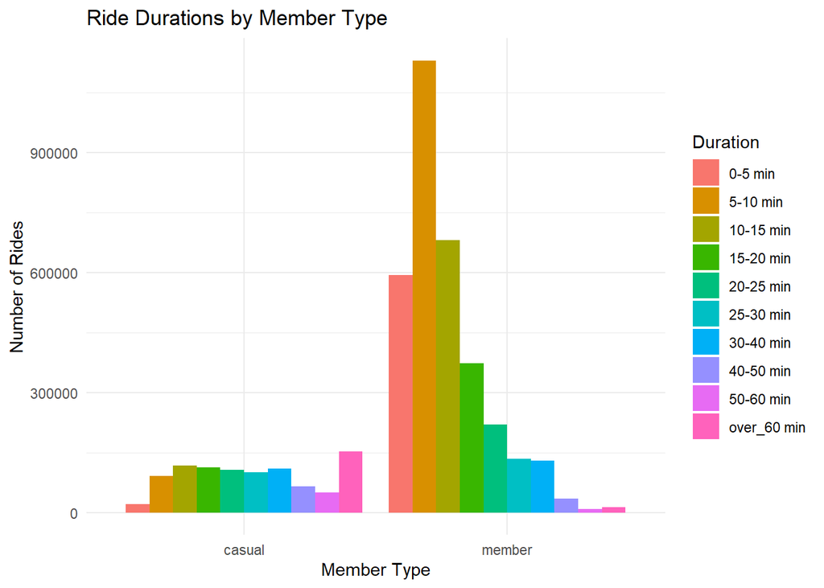

```r
#First we must create the time groupings for the visualizations as there will be far to many individual times to show - grouping into categories or chunks of time will make the visualization effective and understandable
ridetime_summary <- all_trips_v2 %>%
  group_by(member_casual) %>%
  summarise(
    total_rides = n(),
    "0-5 min" = sum(ride_length >= 0 & ride_length < 301, na.rm = TRUE),
    "5-10 min" = sum(ride_length >= 301 & ride_length < 601, na.rm = TRUE),
    "10-15 min" = sum(ride_length >= 601 & ride_length < 901, na.rm = TRUE),
    "15-20 min" = sum(ride_length >= 901 & ride_length < 1201, na.rm = TRUE),
    "20-25 min" = sum(ride_length >= 1201 & ride_length < 1501, na.rm = TRUE),
    "25-30 min" = sum(ride_length >= 1501 & ride_length < 1801, na.rm = TRUE),
    "30-40 min" = sum(ride_length >= 1801 & ride_length < 2401, na.rm = TRUE),
    "40-50 min" = sum(ride_length >= 2401 & ride_length < 3001, na.rm = TRUE),
    "50-60 min" = sum(ride_length >= 3001 & ride_length < 3601, na.rm = TRUE),
    "over_60 min" = sum(ride_length >= 3601, na.rm = TRUE),
  )

#then we transform the data from wide to long to make it easier to create visualizations
ridetime_long <- tidyr::pivot_longer(ridetime_summary,
                                     cols = c("0-5 min", "5-10 min","10-15 min", "15-20 min","20-25 min", "25-30 min", "30-40 min", "40-50 min","50-60 min","over_60 min"  ),
                                     names_to = "duration",
                                     values_to = "count")


#for the visualizations we want to specify the order of the time grouping for ride duration
duration_order <- c("0-5 min", "5-10 min", "10-15 min", "15-20 min", "20-25 min", "25-30 min", "30-40 min", "40-50 min", "50-60 min", "over_60 min") #this defines the order left to right

#below converts the duration column in your ridetime_long dataframe to a factor with the specified order
ridetime_long$duration <- factor(ridetime_long$duration, levels = duration_order)

#ride duration by member type axis
ggplot(ridetime_long, aes(x = member_casual, y = count, fill = duration)) +
  geom_bar(stat = "identity", position = "dodge") +
  labs(title = "Ride Durations by Member Type",
       x = "Member Type",
       y = "Number of Rides",
       fill = "Duration") +
  scale_y_continuous(labels=function(n){format(n, scientific = FALSE)}) +
  theme_minimal()
```

```r
ggsave("BAR-ride_duration_by_member_type-axis.png")
```

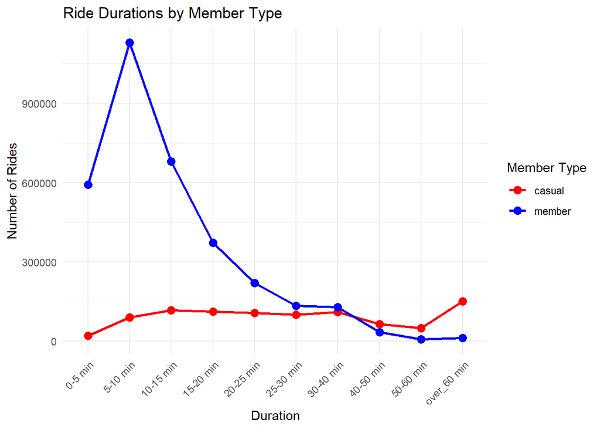

```r
#as a line graph
ggplot(ridetime_long, aes(x = duration, y = count, color = member_casual, group = member_casual)) +
  geom_line(linewidth = 1) +
  geom_point(size = 3) +
  labs(title = "Ride Durations by Member Type",
       x = "Duration",
       y = "Number of Rides",
       color = "Member Type") +
  scale_y_continuous(labels = function(n){format(n, scientific = FALSE)}) +
  scale_color_manual(values = c("red","blue")) +
#  scale_fill_manual(values = c("red", "blue")) + #this was the wrong color of blue and red
  theme_minimal() +
  theme(axis.text.x = element_text(angle = 45, hjust = 1))
```

```r
ggsave("LINE-ride_duration_by_member_type-time_axis.png")
```

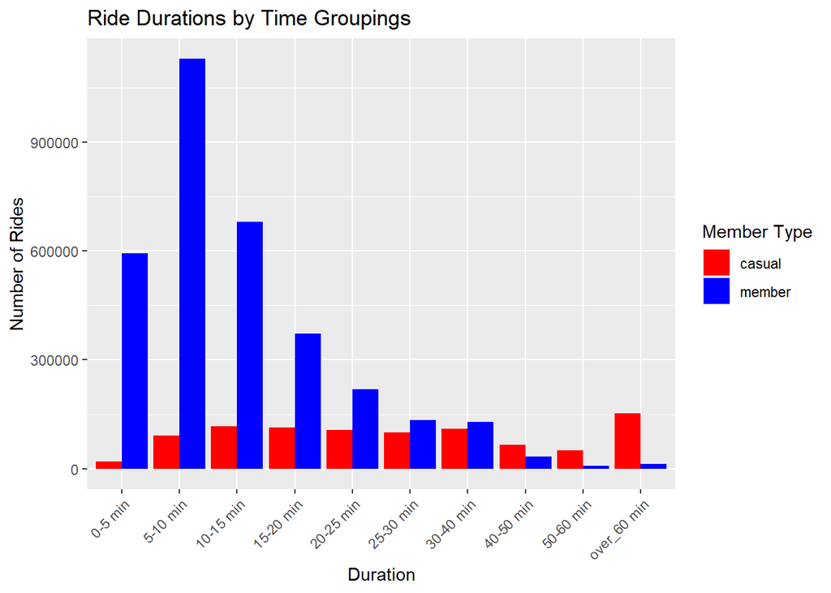

```r
#ride duration by time grouping axis
ggplot(ridetime_long, aes(x = duration, y = count, fill = member_casual)) +
  geom_bar(stat = "identity", position = "dodge") +
  labs(title = "Ride Durations by Time Groupings",
       x = "Duration",
       y = "Number of Rides",
       fill = "Member Type") +
  scale_y_continuous(labels=function(n){format(n, scientific = FALSE)}) +
#  scale_color_manual(values = c("blue", "red")) +
  scale_fill_manual(values = c("red", "blue")) +
  theme(axis.text.x = element_text(angle = 45, hjust = 1))
```

```r
ggsave("BAR-ride_duration_by_Time_Groupings-time_axis.png")
```

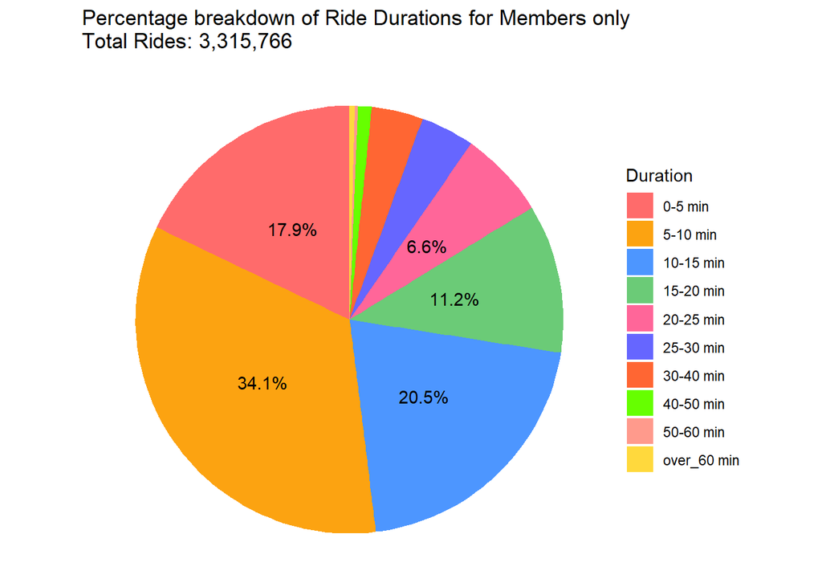

```r
#creating some stats for use percentage by time category and member_casual = member only
# Filter for members only and calculate percentages
member_percentages <- ridetime_summary %>%
  filter(member_casual == "member") %>%
  select(-member_casual, -total_rides) %>%
  pivot_longer(cols = everything(), names_to = "duration", values_to = "count") %>%
  mutate(
    percentage = count / sum(count),
    duration = factor(duration, levels = duration_order)
  ) %>%
  arrange(duration)

# Calculate the total number of member rides
total_member_rides <- ridetime_summary %>%
  filter(member_casual == "member") %>%
  pull(total_rides)

#using a pie chart to visualize
ggplot(member_percentages, aes(x = "", y = percentage, fill = duration)) +
  geom_bar(stat = "identity", width = 1) +
  coord_polar("y", start = 0) +
  scale_fill_manual(values = c("#FF6B6B", "#FCA311", "#4D96FF", "#6BCB77", "#FF6699", "#6666FF", "#ff6633", "#66FF00", "#FF9A8C", "#FFD93D")) +
  theme_void() +
  theme(legend.position = "right") +
  # Only show labels for slices with 5% or more
  geom_text(aes(label = ifelse(percentage >= 0.05, scales::percent(percentage, accuracy = 0.1), "")),
            position = position_stack(vjust = 0.5)) +
  labs(title = paste("Percentage breakdown of Ride Durations for Members only\nTotal Rides:", format(total_member_rides, big.mark = ",")),
       fill = "Duration")
```

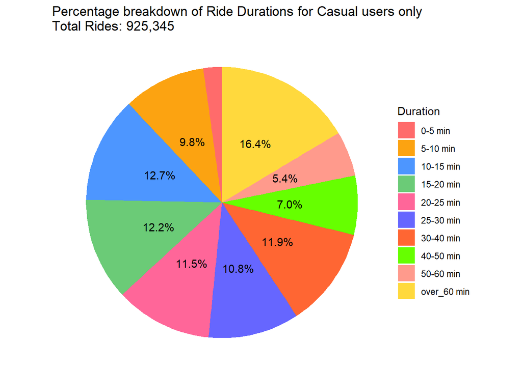

```r
ggsave("member_ride_duration_percentages_pie_chart.png")
#creating some stats for use percentage by time category and member_casual = casual only
casual_percentages <- ridetime_summary %>%
  filter(member_casual == "casual") %>%
  select(-member_casual, -total_rides) %>%
  pivot_longer(cols = everything(), names_to = "duration", values_to = "count") %>%
  mutate(
    percentage = count / sum(count),
    duration = factor(duration, levels = duration_order)
  ) %>%
  arrange(duration)

# Calculate the total number of casual rides
total_casual_rides <- ridetime_summary %>%
  filter(member_casual == "casual") %>%
  pull(total_rides)

#using a pie chart to visualize
ggplot(casual_percentages, aes(x = "", y = percentage, fill = duration)) +
  geom_bar(stat = "identity", width = 1) +
  coord_polar("y", start = 0) +
  scale_fill_manual(values = c("#FF6B6B", "#FCA311", "#4D96FF", "#6BCB77", "#FF6699", "#6666FF", "#ff6633", "#66FF00", "#FF9A8C", "#FFD93D")) +
  theme_void() +
  theme(legend.position = "right") +
  # Only show labels for slices with 5% or more
  geom_text(aes(label = ifelse(percentage >= 0.05, scales::percent(percentage, accuracy = 0.1), "")),
            position = position_stack(vjust = 0.5)) +
  labs(title = paste("Percentage breakdown of Ride Durations for Casual users only\nTotal Rides:", format(total_casual_rides, big.mark = ",")),
       fill = "Duration")
```

```r
ggsave("casual_ride_duration_percentages_pie_chart.png")
```

##Observations from the visualizations What did we see in the visualizations? *Members use the bikes far more frequently than casual users* Members time with the bikes is less than 15 min for the majority of the member transactions *the most common amounts of time for members to have the bikes is between 5 - 10 minutes, followed by 10 - 15 minutes and 0 - 5 minutes

Next let’s look at some percentages based on the ridetime_summary we created

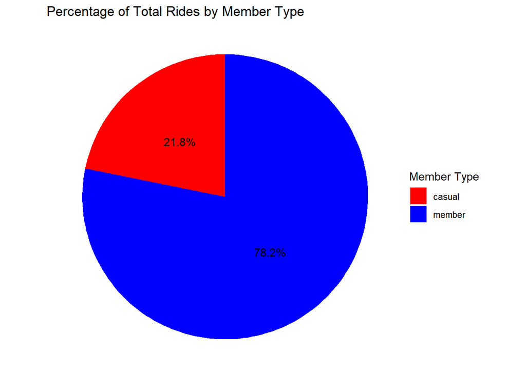

```r
# Calculate percentages
total_rides_pct <- ridetime_summary %>%
  mutate(pct = total_rides / sum(total_rides) * 100)

# Visualization
ggplot(total_rides_pct, aes(x = "", y = pct, fill = member_casual)) +
  geom_bar(stat = "identity", width = 1) +
  coord_polar("y", start = 0) +
  theme_void() +
  scale_fill_manual(values = c("red", "blue")) +
  labs(title = "Percentage of Total Rides by Member Type", fill = "Member Type") +
  geom_text(aes(label = paste0(round(pct, 1), "%")), position = position_stack(vjust = 0.5))
```

```r
ggsave("PIE-percentage_of_Total_Rides_by_Member_Type.png")
```

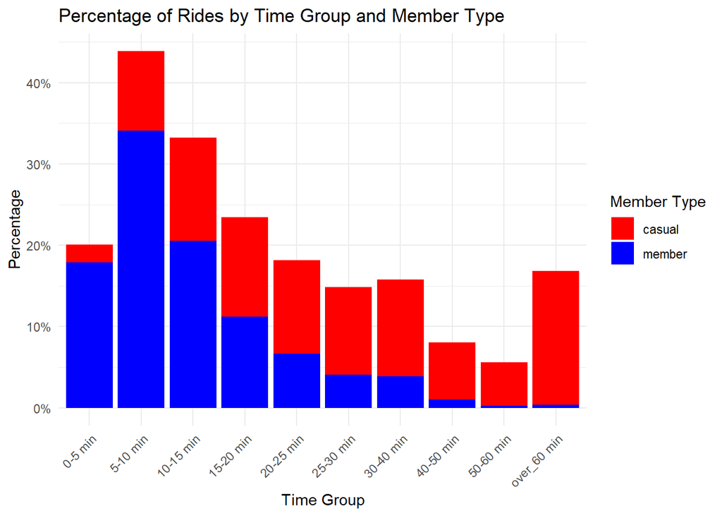

```r
# Reshape data
total_rides_pct_long <- total_rides_pct %>%
  pivot_longer(cols = c(`0-5 min`, `5-10 min`, `10-15 min`, `15-20 min`, `20-25 min`,
                        `25-30 min`, `30-40 min`, `40-50 min`, `50-60 min`, `over_60 min`),
               names_to = "time_group", values_to = "count")

# Calculate percentages
time_group_pct <- total_rides_pct_long %>%
  group_by(time_group) %>%
  mutate(pct = count / sum(count) * 100) %>%
  ungroup()

time_group_vs_total <- total_rides_pct_long %>%
  group_by(member_casual) %>%
  mutate(pct_of_total = count / total_rides * 100) %>%
  ungroup()

# Order the time_group factor
time_group_vs_total$time_group <- factor(time_group_vs_total$time_group, levels = duration_order)

# Visualization
ggplot(time_group_vs_total, aes(x = time_group, y = pct_of_total, fill = member_casual)) +
  geom_bar(stat = "identity", position = "stack") +
  theme_minimal() +
  theme(axis.text.x = element_text(angle = 45, hjust = 1)) +
  scale_fill_manual(values = c("red", "blue")) +
  labs(title = "Percentage of Rides by Time Group and Member Type",
       x = "Time Group", y = "Percentage", fill = "Member Type") +
  scale_y_continuous(labels = scales::percent_format(scale = 1))
```

```r
ggsave("BAR-percentage_of_rides_by_time_group_and_member_type.png")
```

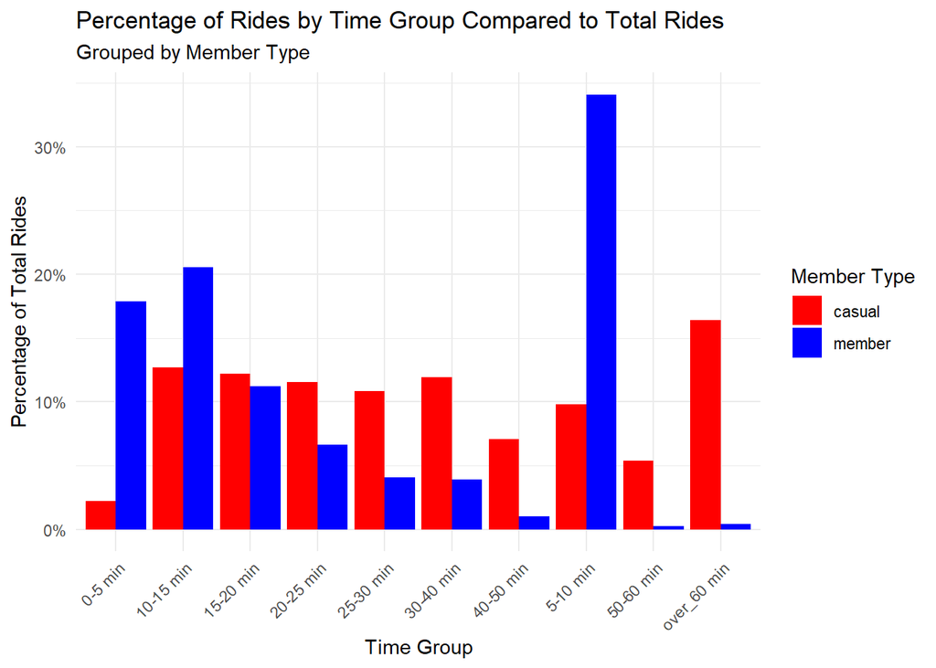

```r
# Calculate percentages
time_group_vs_total <- total_rides_pct_long %>%
  group_by(member_casual) %>%
  mutate(pct_of_total = count / total_rides * 100) %>%
  ungroup()


# Visualization
ggplot(time_group_vs_total, aes(x = time_group, y = pct_of_total, fill = member_casual)) +
  geom_bar(stat = "identity", position = "dodge") +
  theme_minimal() +
  theme(axis.text.x = element_text(angle = 45, hjust = 1)) +
  scale_fill_manual(values = c("red", "blue")) +
  labs(title = "Percentage of Rides by Time Group Compared to Total Rides",
       subtitle = "Grouped by Member Type",
       x = "Time Group", y = "Percentage of Total Rides", fill = "Member Type") +
  scale_y_continuous(labels = scales::percent_format(scale = 1))
```

```r
ggsave("BAR-percentage_of_rides_by_time_group_compared_to_total_rides.png")
```

lets look at some percentages for the quantity of rides for member and casual

```r
# Create a function to format month_year
format_month_year <- function(month, year) {
  paste(month.abb[as.numeric(month)], substr(year, 3, 4))
}

#create a custom order for the months
month_order <- c("Jan 19", "Feb 19", "Mar 19", "Apr 19", "May 19", "Jun 19", "Jul 19", "Aug 19", "Sep 19", "Oct 19", "Nov 19", "Dec 19", "Jan 20", "Feb 20", "Mar 20")

# Calculate percentages
ride_percentages <- all_trips_v2 %>%
  mutate(
    formatted_month_year = format_month_year(month, year),
    formatted_month_year = factor(formatted_month_year, levels = month_order)
  ) %>%
  group_by(formatted_month_year, member_casual) %>%
  summarise(count = n(), .groups = "drop") %>%
  group_by(formatted_month_year) %>%
  mutate(
    total = sum(count),
    percentage = count / total * 100
  ) %>%
  ungroup()

# look at the statistics
print(ride_percentages)
```

```
## # A tibble: 30 × 5
##    formatted_month_year member_casual  count  total percentage
##    <fct>                <chr>          <int>  <int>      <dbl>
##  1 Jan 19               casual          4602 103272       4.46
##  2 Jan 19               member         98670 103272      95.5
##  3 Feb 19               casual          2638  96186       2.74
##  4 Feb 19               member         93548  96186      97.3
##  5 Mar 19               casual         15923 165611       9.61
##  6 Mar 19               member        149688 165611      90.4
##  7 Apr 19               casual         47744 265310      18.0
##  8 Apr 19               member        217566 265310      82.0
##  9 May 19               casual         81624 367458      22.2
## 10 May 19               member        285834 367458      77.8
## # ℹ 20 more rows
```

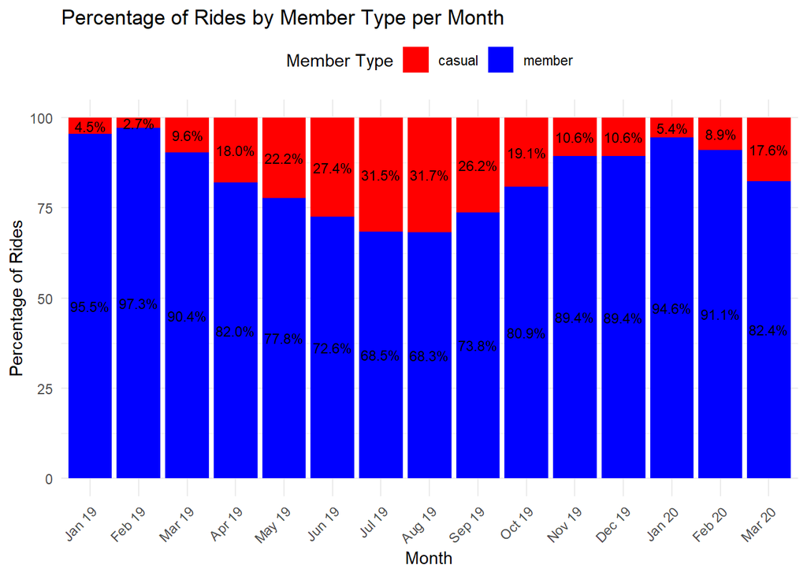

```r
# Creating a visualization
ggplot(ride_percentages, aes(x = formatted_month_year, y = percentage, fill = member_casual)) +
  geom_bar(stat = "identity", position = "stack") +
  geom_text(aes(label = sprintf("%.1f%%", percentage)),
            position = position_stack(vjust = 0.5),
            size = 3) +
  scale_fill_manual(values = c("casual" = "red", "member" = "blue")) +
  labs(
    title = "Percentage of Rides by Member Type per Month",
    x = "Month",
    y = "Percentage of Rides",
    fill = "Member Type"
  ) +
  theme_minimal() +
  theme(
    axis.text.x = element_text(angle = 45, hjust = 1),
    legend.position = "top"
  )
```

```r
# Save the plot
ggsave("rides_by_member_type_per_month.png")
```

##===================================== # STEP 4: CONDUCT DESCRIPTIVE ANALYSIS ##===================================== Now that we have addressed the negative ride_length times and also viewed a few quick visualizations regarding the member type vs ride_length time groups and quantity of rides, lets looks at some more statistical analysis.

Let’s review the mean, median, max and min of all the transaction ride lengths individually and then a summary to display it in a way that is easier to digest

```r
# Descriptive analysis on ride_length (all figures in seconds)
mean(all_trips_v2$ride_length) #straight average (total ride length / rides)
```

```
## [1] 1439.315
```

```r
median(all_trips_v2$ride_length) #midpoint number in the ascending array of ride lengths
```

```
## [1] 691
```

```r
max(all_trips_v2$ride_length) #longest ride
```

```
## [1] 10632022
```

```r
min(all_trips_v2$ride_length) #shortest ride
```

```
## [1] 1
```

```r
summary(all_trips_v2$ride_length) #this is the above but condensed to 1 line of code and provides a summary that is easier to understand and digest
```

```
##     Min.  1st Qu.   Median     Mean  3rd Qu.     Max.
##        1      402      691     1439     1250 10632022
```

Let’s compare by membership type member vs. casual

```r
aggregate(all_trips_v2$ride_length ~ all_trips_v2$member_casual, FUN = mean)
```

```
##   all_trips_v2$member_casual all_trips_v2$ride_length
## 1                     casual                3556.8495
## 2                     member                 848.3654
```

```r
aggregate(all_trips_v2$ride_length ~ all_trips_v2$member_casual, FUN = median)
```

```
##   all_trips_v2$member_casual all_trips_v2$ride_length
## 1                     casual                     1542
## 2                     member                      579
```

```r
aggregate(all_trips_v2$ride_length ~ all_trips_v2$member_casual, FUN = max)
```

```
##   all_trips_v2$member_casual all_trips_v2$ride_length
## 1                     casual                 10632022
## 2                     member                  9056634
```

```r
aggregate(all_trips_v2$ride_length ~ all_trips_v2$member_casual, FUN = min)
```

```
##   all_trips_v2$member_casual all_trips_v2$ride_length
## 1                     casual                        2
## 2                     member                        1
```

Let’s compare the average ride time by each day for members vs casual users

```r
aggregate(all_trips_v2$ride_length ~ all_trips_v2$member_casual + all_trips_v2$day_of_week, FUN = mean)
```

```
##    all_trips_v2$member_casual all_trips_v2$day_of_week all_trips_v2$ride_length
## 1                      casual                   Friday                3768.9980
## 2                      member                   Friday                 825.5616
## 3                      casual                   Monday                3359.6077
## 4                      member                   Monday                 845.8799
## 5                      casual                 Saturday                3339.9183
## 6                      member                 Saturday                 973.5914
## 7                      casual                   Sunday                3559.2956
## 8                      member                   Sunday                 927.2716
## 9                      casual                 Thursday                3803.1191
## 10                     member                 Thursday                 811.8656
## 11                     casual                  Tuesday                3562.1547
## 12                     member                  Tuesday                 829.8321
## 13                     casual                Wednesday                3702.9008
## 14                     member                Wednesday                 813.8020
```

Here we notice that the days of the week are out of order, so we will need to correct it.

```r
all_trips_v2$day_of_week <- ordered(all_trips_v2$day_of_week, levels=c("Sunday", "Monday", "Tuesday", "Wednesday", "Thursday", "Friday", "Saturday"))
```

Now, let’s run the average ride time by each day for members vs casual users again

```r
aggregate(all_trips_v2$ride_length ~ all_trips_v2$member_casual + all_trips_v2$day_of_week, FUN = mean)
```

```
##    all_trips_v2$member_casual all_trips_v2$day_of_week all_trips_v2$ride_length
## 1                      casual                   Sunday                3559.2956
## 2                      member                   Sunday                 927.2716
## 3                      casual                   Monday                3359.6077
## 4                      member                   Monday                 845.8799
## 5                      casual                  Tuesday                3562.1547
## 6                      member                  Tuesday                 829.8321
## 7                      casual                Wednesday                3702.9008
## 8                      member                Wednesday                 813.8020
## 9                      casual                 Thursday                3803.1191
## 10                     member                 Thursday                 811.8656
## 11                     casual                   Friday                3768.9980
## 12                     member                   Friday                 825.5616
## 13                     casual                 Saturday                3339.9183
## 14                     member                 Saturday                 973.5914
```

Let’s continue to analyze ridership data by type and weekday.

```r
all_trips_v2 %>%
  mutate(weekday = wday(started_at, label = TRUE)) %>%  #creates weekday field using wday()
  group_by(member_casual, weekday) %>%  #groups by usertype and weekday
  summarise(number_of_rides = n()                           #calculates the number of rides and average duration
            ,average_duration_minutes = mean(ride_length/60,2)) %>%         # calculates the average duration
  arrange(member_casual, weekday)                               # sorts
```

```
## # A tibble: 14 × 4
## # Groups:   member_casual [2]
##    member_casual weekday number_of_rides average_duration_minutes
##    <chr>         <ord>             <int>                    <dbl>
##  1 casual        Sun              185059                    27.0
##  2 casual        Mon              105188                    25.7
##  3 casual        Tue               93238                    23.8
##  4 casual        Wed               94946                    23.6
##  5 casual        Thu              105599                    23.8
##  6 casual        Fri              125779                    24.9
##  7 casual        Sat              215536                    27.6
##  8 member        Sun              292198                    10.4
##  9 member        Mon              520703                     9.52
## 10 member        Tue              566722                     9.52
## 11 member        Wed              558254                     9.57
## 12 member        Thu              548160                     9.52
## 13 member        Fri              512462                     9.38
## 14 member        Sat              317267                    10.5
```

let’s visualize by weekday

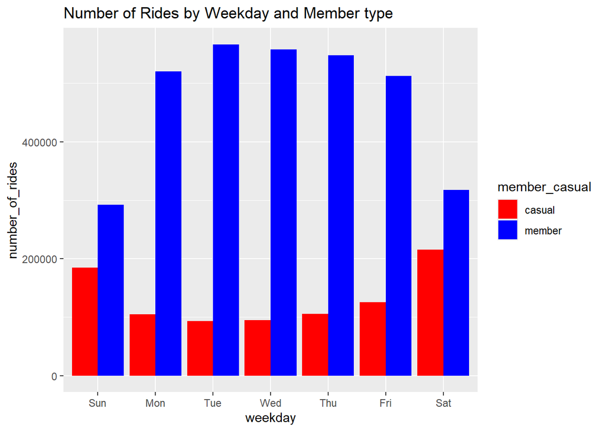

```r
all_trips_v2 %>%
  mutate(weekday = wday(started_at, label = TRUE)) %>%
  group_by(member_casual, weekday) %>%
  summarise(number_of_rides = n()
            ,average_duration_minutes = mean(ride_length)) %>%
  arrange(member_casual, weekday)  %>%
  ggplot(aes(x = weekday, y = number_of_rides, fill = member_casual)) +
  geom_col(position = "dodge") +
  labs(title = "Number of Rides by Weekday and Member type") +
  scale_y_continuous(labels=function(n){format(n, scientific = FALSE)}) +
  scale_fill_manual(values = c("red", "blue"))
```

```r
#  scale_color_manual(values = c("blue", "red")) #this was giving a different red and blue color
ggsave("BAR-number_rides_by_weekday_and_member_type-weekday_axis.png")
```

##Observations from the visualizations What did we see in the visualizations? *Members are far more likely to use the bikes during the week and causal non-members are more likely to use the bikes on weekends

let’s visualize by month

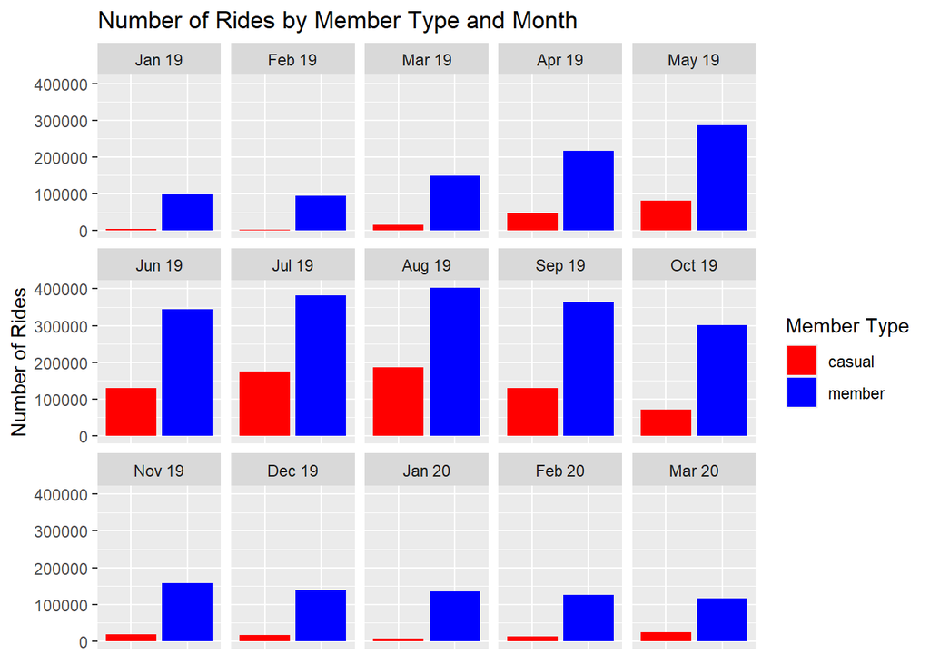

```r
all_trips_v2 %>%
  mutate(
    # Convert month_year to the new format
    month_year_new = paste(
      month.abb[as.numeric(substr(month_year, 1, 2))],
      substr(month_year, 6, 7),
      sep = " "
    ),
    # Create a factor with custom order
    month_year_factor = factor(month_year_new, levels = month_order)
  ) %>%
  group_by(member_casual, month_year_factor) %>%
  summarise(
    number_of_rides = n(),
    average_duration_minutes = mean(ride_length),
    .groups = "drop"
  ) %>%
  ggplot(aes(x = member_casual, y = number_of_rides, fill = member_casual)) +
  geom_col(position = "dodge") +
  scale_y_continuous(labels = function(n){format(n, scientific = FALSE)}) +
#  scale_color_manual(values = c("blue", "red")) +
  scale_fill_manual(values = c("red", "blue")) +
  facet_wrap(~month_year_factor, ncol = 5) +
  theme(
    axis.text.x = element_blank(),  # Remove x-axis text
    axis.ticks.x = element_blank(), # Remove x-axis ticks
    axis.title.x = element_blank()  # Remove x-axis title
  ) +
  labs(
    title = "Number of Rides by Member Type and Month",
    y = "Number of Rides",
    fill = "Member Type"
  )
```

```r
ggsave("BAR-number_rides_by_member_type_and_month-facet.png")
```

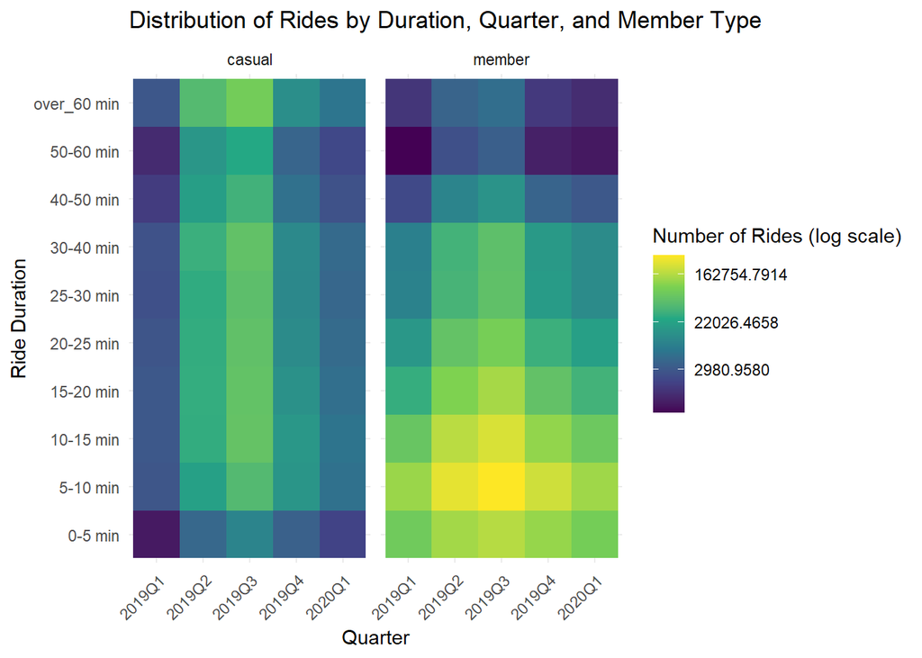

```r
# Function to determine quarter
get_quarter <- function(date) {
  quarter <- quarter(date)
  year <- year(date)
  return(paste(year, "Q", quarter, sep=""))
}

# Define the order of quarters
quarter_order <- c("2019Q1", "2019Q2", "2019Q3", "2019Q4", "2020Q1")
#as a heat map:
all_trips_v2 %>%
  mutate(
    quarter_group = get_quarter(started_at),
    quarter_factor = factor(quarter_group, levels = quarter_order),
    time_group = case_when(
      ride_length <= 301 ~ "0-5 min",
      ride_length <= 601 ~ "5-10 min",
      ride_length <= 901 ~ "10-15 min",
      ride_length <= 1201 ~ "15-20 min",
      ride_length <= 1501 ~ "20-25 min",
      ride_length <= 1801 ~ "25-30 min",
      ride_length <= 2401 ~ "30-40 min",
      ride_length <= 3001 ~ "40-50 min",
      ride_length <= 3601 ~ "50-60 min",
      ride_length > 3601 ~ "over_60 min"
    ),
    time_group = factor(time_group, levels = c("0-5 min", "5-10 min", "10-15 min", "15-20 min",
                                               "20-25 min", "25-30 min", "30-40 min", "40-50 min",
                                               "50-60 min", "over_60 min"))
  ) %>%
  group_by(member_casual, quarter_factor, time_group) %>%
  summarise(
    number_of_rides = n(),
    .groups = "drop"
  ) %>%
  ggplot(aes(x = quarter_factor, y = time_group, fill = number_of_rides)) +
  geom_tile() +
  facet_wrap(~member_casual) +
  scale_fill_viridis_c(trans = "log", name = "Number of Rides (log scale)") +
  theme_minimal() +
  theme(axis.text.x = element_text(angle = 45, hjust = 1)) +
  labs(title = "Distribution of Rides by Duration, Quarter, and Member Type",
       x = "Quarter", y = "Ride Duration")
```

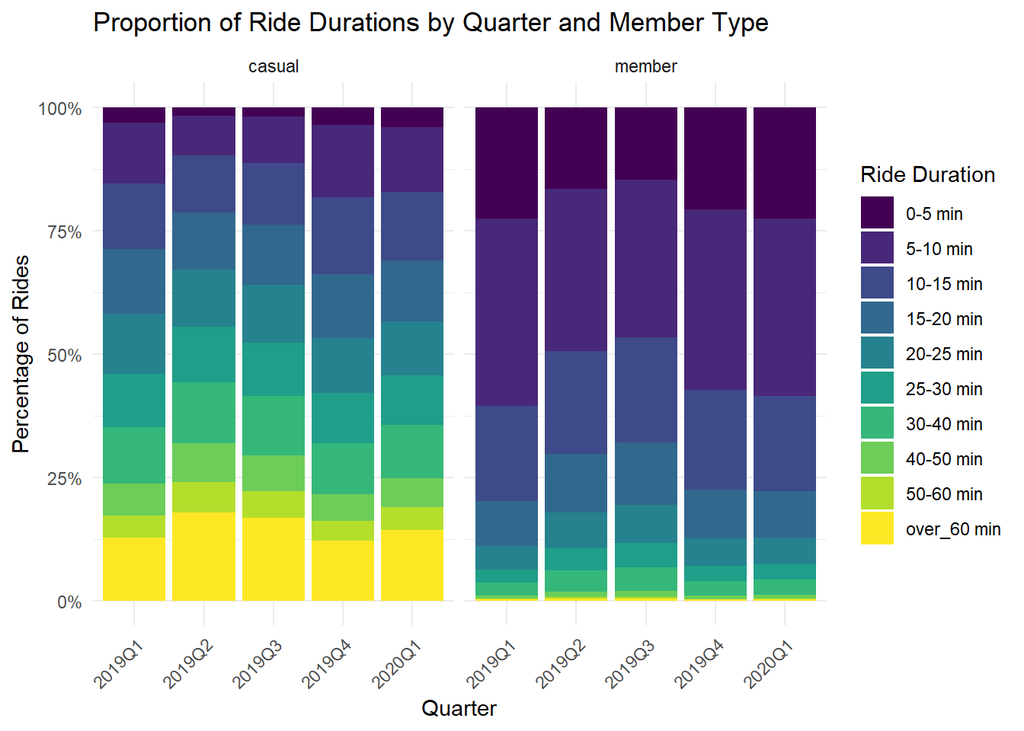

```r
ggsave("heatmap_rides_by_duration_quarter_member_type.png")
#as stacked Bar charts:
all_trips_v2 %>%
  mutate(
    quarter_group = get_quarter(started_at),
    quarter_factor = factor(quarter_group, levels = quarter_order),
    time_group = case_when(
      ride_length <= 301 ~ "0-5 min",
      ride_length <= 601 ~ "5-10 min",
      ride_length <= 901 ~ "10-15 min",
      ride_length <= 1201 ~ "15-20 min",
      ride_length <= 1501 ~ "20-25 min",
      ride_length <= 1801 ~ "25-30 min",
      ride_length <= 2401 ~ "30-40 min",
      ride_length <= 3001 ~ "40-50 min",
      ride_length <= 3601 ~ "50-60 min",
      ride_length > 3601 ~ "over_60 min"
    ),
    time_group = factor(time_group, levels = c("0-5 min", "5-10 min", "10-15 min", "15-20 min",
                                               "20-25 min", "25-30 min", "30-40 min", "40-50 min",
                                               "50-60 min", "over_60 min"))
  ) %>%
  group_by(member_casual, quarter_factor, time_group) %>%
  summarise(
    number_of_rides = n(),
    .groups = "drop"
  ) %>%
  group_by(member_casual, quarter_factor) %>%
  mutate(percentage = number_of_rides / sum(number_of_rides)) %>%
  ggplot(aes(x = quarter_factor, y = percentage, fill = time_group)) +
  geom_bar(stat = "identity") +
  facet_wrap(~member_casual) +
  scale_fill_viridis_d() +
  scale_y_continuous(labels = scales::percent_format(accuracy = 1)) +
  theme_minimal() +
  theme(axis.text.x = element_text(angle = 45, hjust = 1)) +
  labs(title = "Proportion of Ride Durations by Quarter and Member Type",
       x = "Quarter", y = "Percentage of Rides", fill = "Ride Duration")
```

```r
ggsave("stacked_bar_ride_durations_percentage_by_quarter_member_type.png")
```

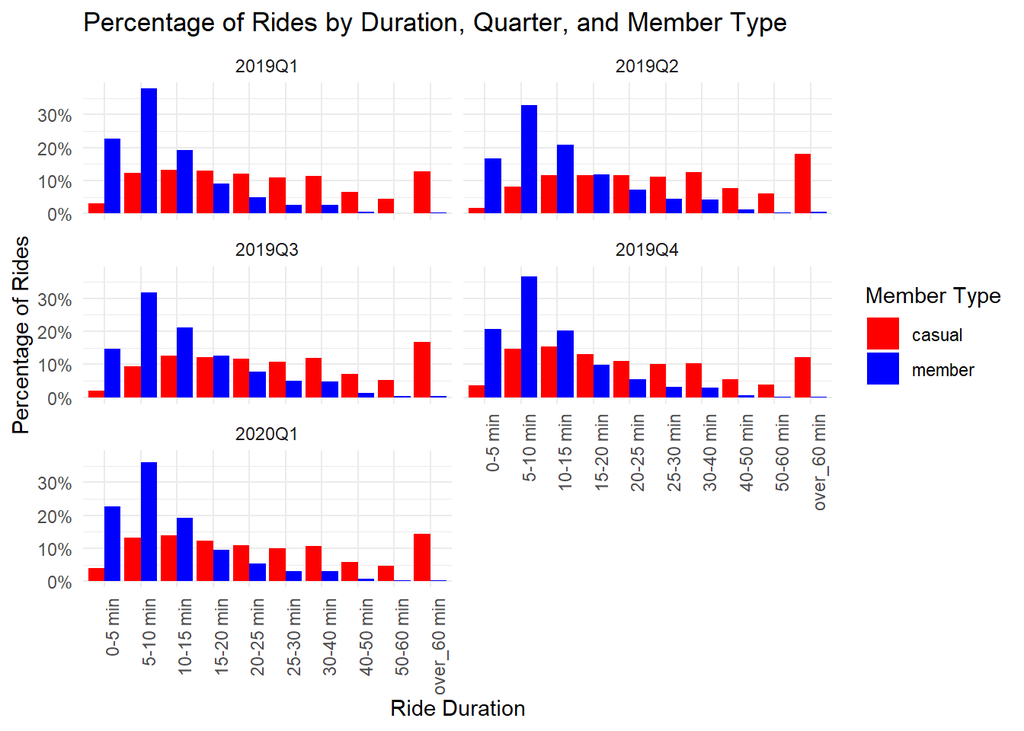

```r
# as a Grouped Bar Chart
all_trips_v2 %>%
  mutate(
    quarter_group = get_quarter(started_at),
    quarter_factor = factor(quarter_group, levels = quarter_order),
    time_group = case_when(
      ride_length <= 301 ~ "0-5 min",
      ride_length <= 601 ~ "5-10 min",
      ride_length <= 901 ~ "10-15 min",
      ride_length <= 1201 ~ "15-20 min",
      ride_length <= 1501 ~ "20-25 min",
      ride_length <= 1801 ~ "25-30 min",
      ride_length <= 2401 ~ "30-40 min",
      ride_length <= 3001 ~ "40-50 min",
      ride_length <= 3601 ~ "50-60 min",
      ride_length > 3601 ~ "over_60 min"
    ),
    time_group = factor(time_group, levels = c("0-5 min", "5-10 min", "10-15 min", "15-20 min",
                                               "20-25 min", "25-30 min", "30-40 min", "40-50 min",
                                               "50-60 min", "over_60 min"))
  ) %>%
  group_by(member_casual, quarter_factor, time_group) %>%
  summarise(
    number_of_rides = n(),
    .groups = "drop"
  ) %>%
  group_by(quarter_factor, member_casual) %>%
  mutate(percentage = number_of_rides / sum(number_of_rides)) %>%
  ggplot(aes(x = time_group, y = percentage, fill = member_casual)) +
  geom_bar(stat = "identity", position = "dodge") +
  facet_wrap(~quarter_factor, ncol = 2) + ##changed from 3 columns to 2 for the presentation vis to fit
  scale_fill_manual(values = c("red", "blue")) +
  scale_y_continuous(labels = scales::percent_format(accuracy = 1)) +  # This line formats the y-axis as percentages
  theme_minimal() +
  theme(axis.text.x = element_text(angle = 90, hjust = 1)) +
  labs(title = "Percentage of Rides by Duration, Quarter, and Member Type",
       x = "Ride Duration", y = "Percentage of Rides", fill = "Member Type")
```

```r
ggsave("grouped_bar_rides_percentage_by_duration_quarter_member_type.png")
```

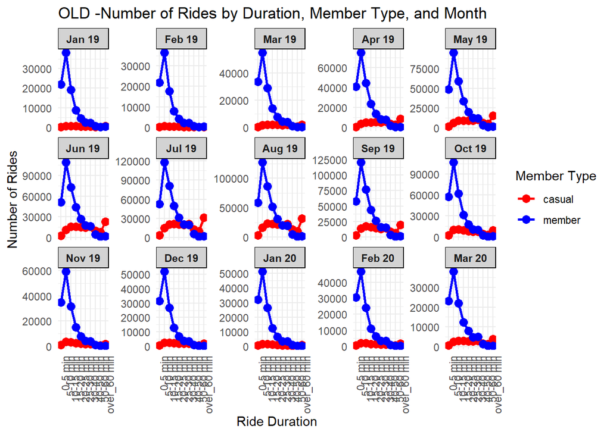

```r
######################################## vis below are too busy to work in a pptx slide (can see time grouping well or just doesn't look right) - none below are being saved
#Line vis by Month:
#set the order of time for the x axis
time_order <- c("0-5 min", "5-10 min", "10-15 min", "15-20 min", "20-25 min", "25-30 min", "30-40 min", "40-50 min", "50-60 min", "over_60 min") #this defines the order left to right

all_trips_v2 %>%
  mutate(
    # Convert month_year to the new format
    month_year_new = paste(
      month.abb[as.numeric(substr(month_year, 1, 2))],
      substr(month_year, 6, 7),
      sep = " "
    ),
    # Create a factor with custom order for months
    month_year_factor = factor(month_year_new, levels = month_order),
    # Create time groups based on ride_length
    time_group = case_when(
      ride_length <= 301 ~ "0-5 min",
      ride_length <= 601 ~ "5-10 min",
      ride_length <= 901 ~ "10-15 min",
      ride_length <= 1201 ~ "15-20 min",
      ride_length <= 1501 ~ "20-25 min",
      ride_length <= 1801 ~ "25-30 min",
      ride_length <= 2401 ~ "30-40 min",
      ride_length <= 3001 ~ "40-50 min",
      ride_length <= 3601 ~ "50-60 min",
      ride_length > 3601 ~ "over_60 min"
    ),
    time_group = factor(time_group, levels = time_order)
  ) %>%
  group_by(member_casual, month_year_factor, time_group) %>%
  summarise(
    number_of_rides = n(),
    .groups = "drop"
  ) %>%
  ggplot(aes(x = time_group, y = number_of_rides, color = member_casual, group = member_casual)) +
  geom_line(linewidth = 1) +
  geom_point(size = 3) +
  facet_wrap(~month_year_factor, ncol = 5, scales = "free_y") +
  scale_y_continuous(labels = function(n){format(n, scientific = FALSE)}) +
  scale_color_manual(values = c("red", "blue")) +
  theme_minimal() +
  theme(
    axis.text.x = element_text(angle = 90, hjust = 1),
    strip.background = element_rect(fill = "lightgray"),
    strip.text = element_text(face = "bold")
  ) +
  labs(
    title = "OLD -Number of Rides by Duration, Member Type, and Month",
    x = "Ride Duration",
    y = "Number of Rides",
    color = "Member Type"
  )
```

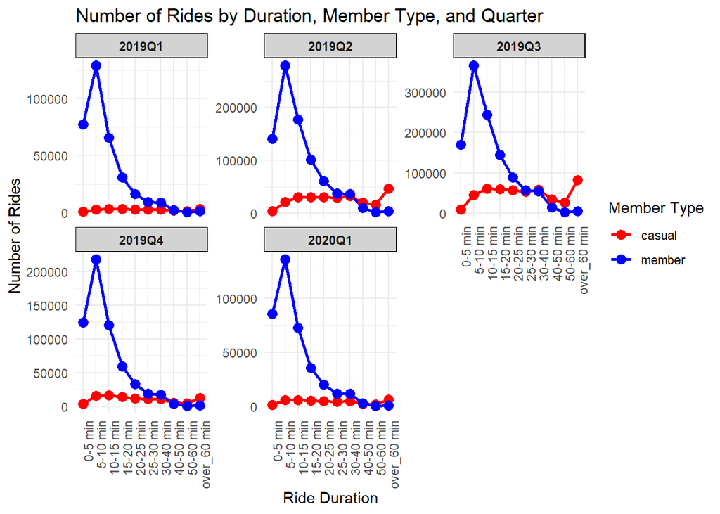

```r
#line vis by quarter:
# Function to determine quarter
get_quarter <- function(date) {
  quarter <- quarter(date)
  year <- year(date)
  return(paste(year, "Q", quarter, sep=""))
}

# Define the order of quarters
quarter_order <- c("2019Q1", "2019Q2", "2019Q3", "2019Q4", "2020Q1")

all_trips_v2 %>%
  mutate(
    # Create quarter group
    quarter_group = get_quarter(started_at),
    quarter_factor = factor(quarter_group, levels = quarter_order),
    # Create time groups based on ride_length
    time_group = case_when(
      ride_length <= 301 ~ "0-5 min",
      ride_length <= 601 ~ "5-10 min",
      ride_length <= 901 ~ "10-15 min",
      ride_length <= 1201 ~ "15-20 min",
      ride_length <= 1501 ~ "20-25 min",
      ride_length <= 1801 ~ "25-30 min",
      ride_length <= 2401 ~ "30-40 min",
      ride_length <= 3001 ~ "40-50 min",
      ride_length <= 3601 ~ "50-60 min",
      ride_length > 3601 ~ "over_60 min"
    ),
    time_group = factor(time_group, levels = c("0-5 min", "5-10 min", "10-15 min", "15-20 min",
                                               "20-25 min", "25-30 min", "30-40 min", "40-50 min",
                                               "50-60 min", "over_60 min"))
  ) %>%
  group_by(member_casual, quarter_factor, time_group) %>%
  summarise(
    number_of_rides = n(),
    .groups = "drop"
  ) %>%
  ggplot(aes(x = time_group, y = number_of_rides, color = member_casual, group = member_casual)) +
  geom_line(linewidth = 1) +
  geom_point(size = 3) +
  facet_wrap(~quarter_factor, ncol = 3, scales = "free_y") +
  scale_y_continuous(labels = function(n){format(n, scientific = FALSE)}) +
  scale_color_manual(values = c("red", "blue")) +
  theme_minimal() +
  theme(
    axis.text.x = element_text(angle = 90, hjust = 1),
    strip.background = element_rect(fill = "lightgray"),
    strip.text = element_text(face = "bold")
  ) +
  labs(
    title = "Number of Rides by Duration, Member Type, and Quarter",
    x = "Ride Duration",
    y = "Number of Rides",
    color = "Member Type"
  )
```

```r
##############
```

##Observations from the visualizations What did we see in the visualizations? *The bikes are used most between May and Oct* members are more likely to use the bikes year round *members are consistent in time usage throughout the year with the 5-10min time frame being the most common by far

*Note: it would be a question for future data collection - is it possible to obtain purpose of trip as I suspect the use of the bikes for members is related to a work commute however there is no data to support the theory at this time

Now let’s look at some summary statistics and visualizations for what time of day for each weekday are the bikes are being picked up and looking at it by Yearly Quarter

```r
# Function to find the mode
find_mode <- function(x) {
  uniq_x <- unique(x)
  uniq_x[which.max(tabulate(match(x, uniq_x)))]
}

summary_stats <- all_trips_v2 %>%
  mutate(
    start_hour = hour(started_at),
    start_hour_12 = ifelse(start_hour == 0, 12, ifelse(start_hour > 12, start_hour - 12, start_hour)),
    am_pm = ifelse(hour(started_at) < 12, "AM", "PM"),
    day_of_week = wday(started_at, label = TRUE, abbr = FALSE)
  ) %>%
  group_by(member_casual, day_of_week) %>%
  summarise(
    most_common_hour = find_mode(start_hour),
    most_common_hour_12 = ifelse(most_common_hour == 0, 12, ifelse(most_common_hour > 12, most_common_hour - 12, most_common_hour)),
    most_common_am_pm = ifelse(most_common_hour < 12, "AM", "PM"),
    .groups = "drop"
  ) %>%
  mutate(
    most_common_time = paste(most_common_hour_12, most_common_am_pm)
  )

print(summary_stats)
```

```
## # A tibble: 14 × 6
##    member_casual day_of_week most_common_hour most_common_hour_12
##    <chr>         <ord>                  <int>               <dbl>
##  1 casual        Sunday                    14                   2
##  2 casual        Monday                    17                   5
##  3 casual        Tuesday                   17                   5
##  4 casual        Wednesday                 17                   5
##  5 casual        Thursday                  17                   5
##  6 casual        Friday                    16                   4
##  7 casual        Saturday                  14                   2
##  8 member        Sunday                    12                  12
##  9 member        Monday                    17                   5
## 10 member        Tuesday                   17                   5
## 11 member        Wednesday                 17                   5
## 12 member        Thursday                  17                   5
## 13 member        Friday                    17                   5
## 14 member        Saturday                  12                  12
## # ℹ 2 more variables: most_common_am_pm <chr>, most_common_time <chr>
```

```r
summary_stats2 <- all_trips_v2 %>%
  mutate(
    start_hour = hour(started_at),
    start_hour_12 = ifelse(start_hour == 0, 12, ifelse(start_hour > 12, start_hour - 12, start_hour)),
    am_pm = ifelse(hour(started_at) < 12, "AM", "PM"),
    day_of_week = wday(started_at, label = TRUE, abbr = FALSE),
    quarter = paste0(year(started_at), " Q", quarter(started_at))
  ) %>%
  filter(quarter %in% c("2019 Q1", "2019 Q2", "2019 Q3", "2019 Q4", "2020 Q1")) %>%
  group_by(member_casual, day_of_week, am_pm, quarter) %>%
  summarise(
    most_common_hour = find_mode(start_hour),
    most_common_hour_12 = ifelse(most_common_hour == 0, 12, ifelse(most_common_hour > 12, most_common_hour - 12, most_common_hour)),
    .groups = "drop"
  ) %>%
  mutate(
    most_common_time = paste(most_common_hour_12, am_pm)
  )

print(summary_stats2)
```

```
## # A tibble: 140 × 7
##    member_casual day_of_week am_pm quarter most_common_hour most_common_hour_12
##    <chr>         <ord>       <chr> <chr>              <int>               <dbl>
##  1 casual        Sunday      AM    2019 Q1               11                  11
##  2 casual        Sunday      AM    2019 Q2               11                  11
##  3 casual        Sunday      AM    2019 Q3               11                  11
##  4 casual        Sunday      AM    2019 Q4               11                  11
##  5 casual        Sunday      AM    2020 Q1               11                  11
##  6 casual        Sunday      PM    2019 Q1               14                   2
##  7 casual        Sunday      PM    2019 Q2               14                   2
##  8 casual        Sunday      PM    2019 Q3               14                   2
##  9 casual        Sunday      PM    2019 Q4               15                   3
## 10 casual        Sunday      PM    2020 Q1               14                   2
## # ℹ 130 more rows
## # ℹ 1 more variable: most_common_time <chr>
```

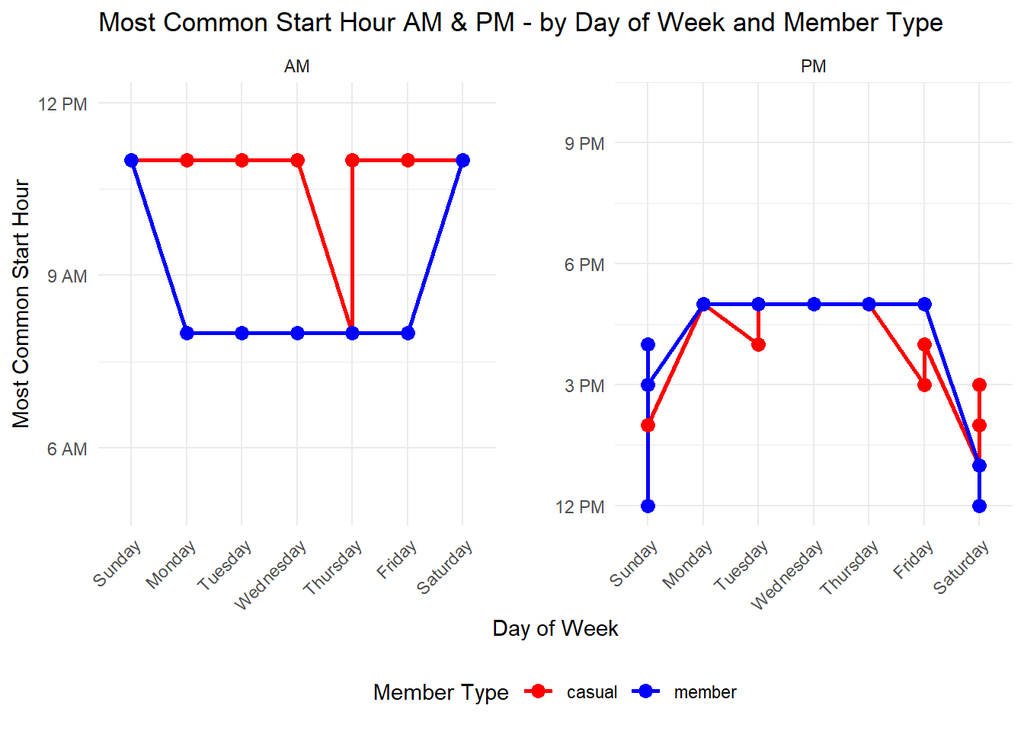

```r
##line plot
summary_stats <- summary_stats %>%
  mutate(am_pm = ifelse(most_common_hour < 12, "AM", "PM")) # here we modify the summary_stats to include an AM/PM indicator

# Now, let's create the plot
ggplot(summary_stats2, aes(x = day_of_week, y = most_common_hour, color = member_casual, group = member_casual)) +
  geom_line(linewidth = 1) +
  geom_point(size = 3) +
  facet_wrap(~ am_pm, ncol = 2, scales = "free_y") +
  theme_minimal() +
  labs(
    title = "Most Common Start Hour AM & PM - by Day of Week and Member Type",
    x = "Day of Week",
    y = "Most Common Start Hour",
    color = "Member Type"
  ) +
  scale_y_continuous(
    breaks = c(6, 9, 12, 15, 18, 21),
    labels = c("6 AM", "9 AM", "12 PM", "3 PM", "6 PM", "9 PM"),
    limits = function(x) {
      if(all(x <= 12)) c(5, 12) else c(12, 22)
    }
  ) +
  scale_color_manual(values = c("red", "blue")) +
  theme(
    axis.text.x = element_text(angle = 45, hjust = 1),
    axis.text.y = element_text(angle = 0, hjust = 1),
    legend.position = "bottom",
    panel.spacing = unit(2, "lines")
  )
```

```r
ggsave("LINE-most_common_am-pm_start-by_memtype.png")
```

[figure not shown]

```r
ggplot(summary_stats2, aes(x = day_of_week, y = most_common_hour, color = member_casual)) +
  geom_line(linewidth = 1) +
  geom_point(aes(shape = am_pm), size = 4) +
  facet_grid(quarter ~ member_casual) +
  theme_minimal() +
  labs(
    title = "Most Common AM & PM Start Hours by Day of Week, Member Type, and Quarter",
    x = "Day of Week",
    y = "Most Common Start Hour",
    color = "Member Type",
    shape = "Time of Day"
  ) +
  scale_y_continuous(
    breaks = c(0, 3, 6, 9, 12, 15, 18, 21),
    labels = c("12 AM", "3 AM", "6 AM", "9 AM", "12 PM", "3 PM", "6 PM", "9 PM"),
    limits = c(0, 23)
  ) +
  scale_color_manual(values = c("casual" = "red", "member" = "blue")) +
  scale_shape_manual(values = c("AM" = 15, "PM" = 16)) +  # Square for AM, Circle for PM
  theme(
    axis.text.x = element_text(angle = 90, hjust = 1),
    axis.text.y = element_text(angle = 0, hjust = 1),
    legend.position = "bottom",
    panel.spacing = unit(1, "lines"),
    strip.text = element_text(size = 10, face = "bold")
  )
```

```r
ggsave("BAR-number_rides_by_member_type_and_day-quarter-facet.png")
```

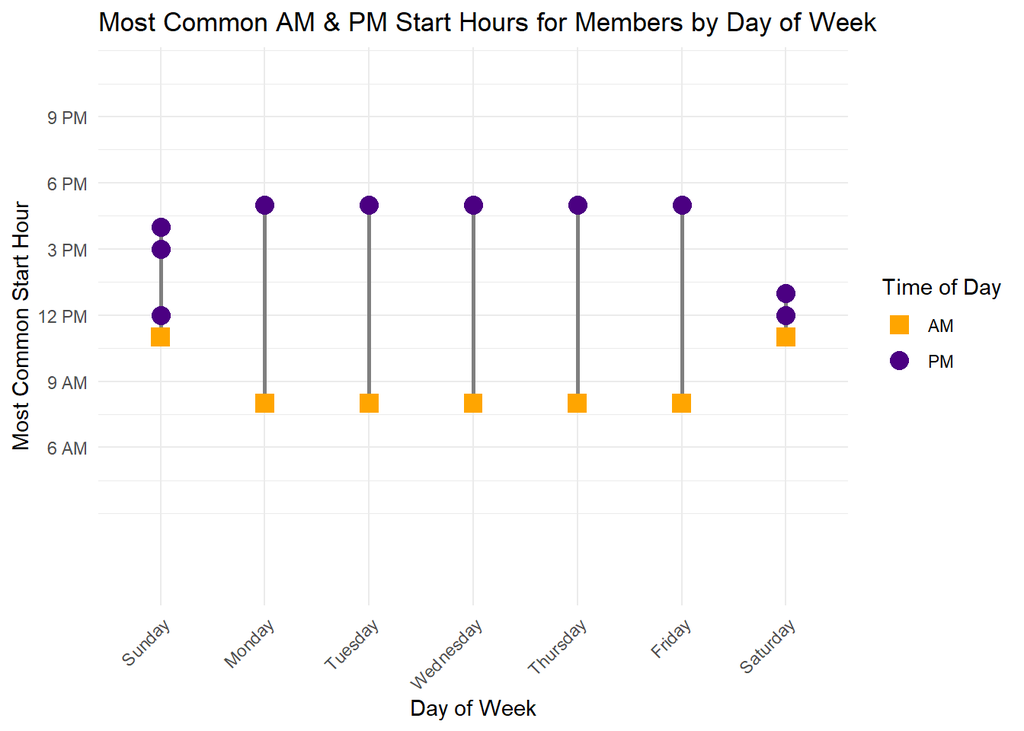

```r
########as the above viz was messy, let's just focus on the project question and create a vis for member only to show the most common AM & PM pick-up times for the bikes
# Filter the data for 'member' only
summary_stats2_member <- summary_stats2 %>%
  filter(member_casual == "member")

# Create the plot
# Create the first plot (without quarter)
#plot1 <-
ggplot(summary_stats2_member, aes(x = day_of_week, y = most_common_hour)) +
  geom_line(linewidth = 1, color = "gray50") +
  geom_point(aes(shape = am_pm, color = am_pm), size = 4) +
  theme_minimal() +
  labs(
    title = "Most Common AM & PM Start Hours for Members by Day of Week",
    x = "Day of Week",
    y = "Most Common Start Hour",
    shape = "Time of Day",
    color = "Time of Day"
  ) +
  scale_y_continuous(
    breaks = c(6, 9, 12, 15, 18, 21),
    labels = c("6 AM", "9 AM", "12 PM", "3 PM", "6 PM", "9 PM"),
    limits = c(0, 23)
  ) +
  scale_shape_manual(values = c("AM" = 15, "PM" = 16)) + # Square for AM, Circle for PM
  scale_color_manual(values = c("AM" = "#FFA500", "PM" = "#4B0082")) + # Orange for AM, Indigo for PM
  theme(
    axis.text.x = element_text(angle = 45, hjust = 1),
    axis.text.y = element_text(angle = 0, hjust = 1),
    legend.position = "right"
  )
```

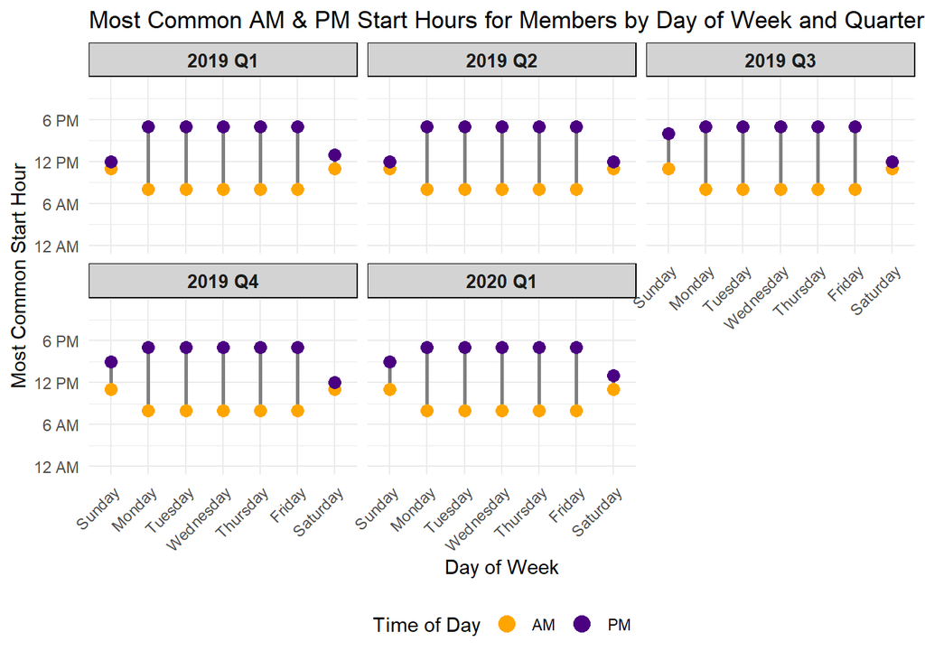

```r
# Save the first plot
ggsave("Most-common_member_pickup_hours_by_day.png")
##---###---###---###--- need to fix colors and Y axis
# Visualization 2: Faceted by year quarter
#plot2 <-
ggplot(summary_stats2_member, aes(x = day_of_week, y = most_common_hour)) +
  geom_line(linewidth = 1, color = "gray50") +
  geom_point(aes(color = am_pm), size = 3, shape = 16) +  # Use filled circle for both AM and PM
  facet_wrap(~ quarter, ncol = 3) +
  theme_minimal() +
  labs(
    title = "Most Common AM & PM Start Hours for Members by Day of Week and Quarter",
    x = "Day of Week",
    y = "Most Common Start Hour",
    color = "Time of Day"  # Change this to color instead of shape
  ) +
  scale_y_continuous(
    breaks = c(0, 6, 12, 18),
    labels = c("12 AM", "6 AM", "12 PM", "6 PM"),
    limits = c(0, 23)
  ) +
  scale_color_manual(values = c("AM" = "#FFA500", "PM" = "#4B0082")) + # Orange for AM, Indigo for PM
  theme(
    axis.text.x = element_text(angle = 45, hjust = 1),
    axis.text.y = element_text(angle = 0, hjust = 1),
    legend.position = "bottom",
    strip.background = element_rect(fill = "lightgray"),
    strip.text = element_text(size = 10, face = "bold")
  ) +
  guides(color = guide_legend(override.aes = list(size = 4)))  # Make legend points larger
```

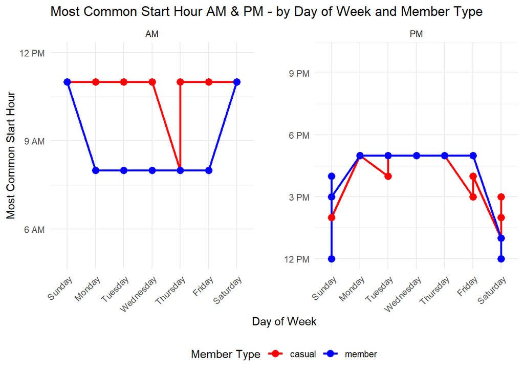

```r
# Save the second plot
ggsave("member_start_hours_by_day_and_quarter.png")
###---###---###---###---##
#################


ggplot(summary_stats2, aes(x = day_of_week, y = most_common_hour, color = member_casual, group = member_casual)) +
  geom_line(linewidth = 1) +
  geom_point(size = 3) +
  facet_wrap(~ am_pm, ncol = 2, scales = "free_y") +
  theme_minimal() +
  labs(
    title = "Most Common Start Hour AM & PM - by Day of Week and Member Type",
    x = "Day of Week",
    y = "Most Common Start Hour",
    color = "Member Type"
  ) +
  scale_y_continuous(
    breaks = c(6, 9, 12, 15, 18, 21),
    labels = c("6 AM", "9 AM", "12 PM", "3 PM", "6 PM", "9 PM"),
    limits = function(x) {
      if(all(x <= 12)) c(5, 12) else c(12, 22)
    }
  ) +
  scale_color_manual(values = c("red", "blue")) +
  theme(
    axis.text.x = element_text(angle = 45, hjust = 1),
    axis.text.y = element_text(angle = 0, hjust = 1),
    legend.position = "bottom",
    panel.spacing = unit(2, "lines")
  )
```

```r
ggsave("LINE-most_common_am-pm_start-by_day-member_only.png")
```

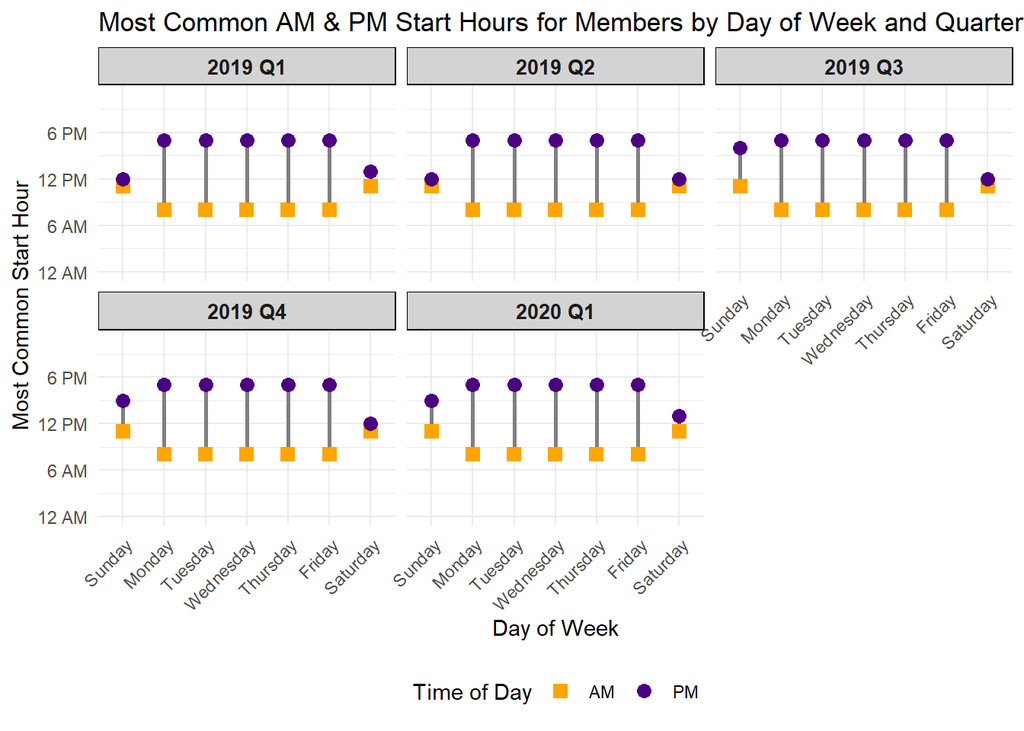

```r
ggplot(summary_stats2_member, aes(x = day_of_week, y = most_common_hour)) +
  geom_line(linewidth = 1, color = "gray50") +
  geom_point(aes(color = am_pm, shape = am_pm), size = 3) +
  facet_wrap(~ quarter, ncol = 3) +
  theme_minimal() +
  labs(
    title = "Most Common AM & PM Start Hours for Members by Day of Week and Quarter",
    x = "Day of Week",
    y = "Most Common Start Hour",
    color = "Time of Day",
    shape = "Time of Day"
  ) +
  scale_y_continuous(
    breaks = c(0, 6, 12, 18),
    labels = c("12 AM", "6 AM", "12 PM", "6 PM"),
    limits = c(0, 23)
  ) +
  scale_color_manual(values = c("AM" = "#FFA500", "PM" = "#4B0082")) +
  scale_shape_manual(values = c("AM" = 15, "PM" = 16)) +
  theme(
    axis.text.x = element_text(angle = 45, hjust = 1),
    axis.text.y = element_text(angle = 0, hjust = 1),
    legend.position = "bottom",
    strip.background = element_rect(fill = "lightgray"),
    strip.text = element_text(size = 10, face = "bold")
  ) +
  guides(color = guide_legend(override.aes = list(size = 3)),
         shape = guide_legend(override.aes = list(size = 3)))
```

```r
ggsave("LINE-most_common_am-pm_start-by_day_quarter-member_only.png")
```

```r
write.csv(all_trips_v2,"all_trips_v2.csv" )
write.csv(ridetime_summary, "ridetime_summary.csv")
write.csv(ridetime_long, "ridetime_long.csv")
write.csv(summary_stats,"summary_stats.csv")
write.csv(summary_stats2,"summary_stats2.csv")
```